# Brexit elasticities core results documentation

# Prepare the dataset

This chunk loads the main data set and prepares the analysis sample. First, the Excel file containing the full applicant data set is imported (it is also pre-filtered). Non-comparable territories and aggregate categories are removed to ensure that only consistent country units remain. Two country groups are then defined: EU member states (`eu_real`), which represent the treated group, and a synthetic comparison set (`eu_synth`) used as the control pool. The data set is restricted to observations belonging to these two groups and to years after 2015. Finally, indicator variables are created to identify whether each observation belongs to the real EU group or the synthetic comparison group, and a categorical grouping variable is constructed for convenience. Basic checks (unique countries, group counts, and data preview) are printed to verify the resulting sample.

```r
library(readxl)
library(dplyr)
# we will pull the data only once and then reference it if necessary
data_full <- read_excel(
  "data_filtered.xlsx",
  sheet = "full_data"
)

data_full <- data_full %>%
  filter(!Domicile_named_country %in% c(
    "St Barthelemy", "St Martin (French part)", "Reunion",
    "Martinique", "Guadeloupe", "Aland Islands",
    "Cyprus (Not otherwise specified)",
    "French West Indies (Not In Use)",
    "Canary Islands", "French Guiana"
  ))

eu_real <- c(
  "Austria", "Belgium", "Bulgaria", "Croatia", "Cyprus (European Union)",
  "Czech Republic", "Denmark", "Estonia", "Finland", "France",
  "Germany", "Greece", "Hungary",  "Italy",
  "Latvia", "Lithuania", "Luxembourg", "Malta", "Netherlands",
  "Poland", "Portugal", "Romania", "Slovakia", "Slovenia",
  "Spain", "Sweden"
)
eu_synth <- c("Australia", "Saudi Arabia", "Russian Federation", "Peru", "Kuwait", "Bahrain","Singapore","Switzerland", "Hong Kong", "United States of America",  "Thailand", "Canada", "Mauritius", "Qatar", "Norway", "Israel", "Malaysia", "Jordan", "Albania", "Serbia", "Ireland", "Jersey", "Macao","United Arab Emirates", "Vietnam [Viet Nam]", "Turkey")

# Now create a filtered copy of the database to use in the regressions
data_UCAS  <- data_full %>%
  filter(Domicile_named_country %in% c(eu_real, eu_synth))

data_UCAS <- data_UCAS %>%
  mutate(
    real_EU  = ifelse(Domicile_named_country %in% eu_real, 1, 0),
    synth_EU = ifelse(Domicile_named_country %in% eu_synth, 1, 0),
    EU_group = case_when(
      Domicile_named_country %in% eu_real ~ "Real_EU",
      Domicile_named_country %in% eu_synth ~ "Synthetic_EU",
      TRUE ~ "Other"
    )
  )

print(unique(data_UCAS$Domicile_named_country))
```

```
##  [1] "Austria"                  "Belgium"
##  [3] "Bulgaria"                 "Denmark"
##  [5] "Finland"                  "France"
##  [7] "Germany"                  "Greece"
##  [9] "Hungary"                  "Ireland"
## [11] "Italy"                    "Luxembourg"
## [13] "Malta"                    "Netherlands"
## [15] "Poland"                   "Portugal"
## [17] "Romania"                  "Spain"
## [19] "Sweden"                   "Estonia"
## [21] "Latvia"                   "Lithuania"
## [23] "Croatia"                  "Slovenia"
## [25] "Czech Republic"           "Slovakia"
## [27] "Cyprus (European Union)"  "Jersey"
## [29] "Russian Federation"       "Mauritius"
## [31] "Norway"                   "Peru"
## [33] "Qatar"                    "Saudi Arabia"
## [35] "Singapore"                "Switzerland"
## [37] "Thailand"                 "United Arab Emirates"
## [39] "Turkey"                   "United States of America"
## [41] "Vietnam [Viet Nam]"       "Serbia"
## [43] "Albania"                  "Australia"
## [45] "Bahrain"                  "Canada"
## [47] "Hong Kong"                "Israel"
## [49] "Jordan"                   "Kuwait"
## [51] "Macao"                    "Malaysia"
```

```r
table(data_UCAS$EU_group)
```

```
##
##      Real_EU Synthetic_EU
##          260          260
```

```r
head(data_UCAS)
```

| Year | Domicile_named_country | Applicants | Accepted_applicants | Acceptance_rate | Applicants_with_no_applications | real_EU | synth_EU | EU_group |
| --- | --- | --- | --- | --- | --- | --- | --- | --- |
| 2016 | Austria | 650 | 370 | 0.5670000000000001 | 5 | 1 | 0 | Real_EU |
| 2017 | Austria | 590 | 340 | 0.5710000000000001 | 0 | 1 | 0 | Real_EU |
| 2018 | Austria | 625 | 335 | 0.537 | 0 | 1 | 0 | Real_EU |
| 2019 | Austria | 625 | 345 | 0.551 | 0 | 1 | 0 | Real_EU |
| 2020 | Austria | 550 | 295 | 0.535 | 0 | 1 | 0 | Real_EU |
| 2021 | Austria | 405 | 165 | 0.41300000000000003 | 0 | 1 | 0 | Real_EU |

Next we perform a sanity check:

```r
data_UCAS <- data_UCAS %>%
  mutate(
    EU_group = case_when(
      Domicile_named_country %in% eu_real  ~ "Real_EU",
      Domicile_named_country %in% eu_synth ~ "Synthetic_EU"
    )
  )
table(data_UCAS$EU_group)
```

```
##
##      Real_EU Synthetic_EU
##          260          260
```

260/10 = 26 real European countries (excl. Ireland because it didn’t face the same restrictions (-1) and excluding UK for obvious reasons (-1)) and 260/10=26 synthetic countries (including Ireland because it is the most plausible counter-factual)

# Saturated DID

## S-DID design with DK errors

This chunk estimates a pooled difference-in-differences model using `fixest::feols` with Driscoll–Kraay (DK) standard errors. We convert the panel object to a plain data frame, ensure `Year` and country identifiers have the correct types, and define the post-treatment period (`Post = 1` for years ≥ 2021) and treatment status (`Treated = 1` for countries in `eu_real`). To allow heterogeneous post effects for each treated country while pooling all non-treated units, we build `treated_factor`: treated countries keep their own country label, while all controls are set to `"CONTROL"` (used as the reference category).

We then estimate three specifications: (1) a two-way fixed-effects model with country and year fixed effects, (2) a country fixed-effects-only model, and (3) a model without fixed effects, all using the same saturated interaction `i(treated_factor, Post, ref = "CONTROL")`. Model summaries are printed for comparison.

The interaction term `i(treated_factor, Post, ref = "CONTROL")` estimates a separate post-treatment effect for each treated country relative to the pooled control group. Formally, the specification can be written as

$$\log(Applicants_{it}) =
\alpha_i + \lambda_t +
\sum_{c \in \mathcal{T}} \beta_c
\left( \mathbf{1}\{i = c\} \times Post_t \right)
+ \varepsilon_{it},$$

where $i$ indexes countries and $t$ indexes years, $\alpha_i$ and $\lambda_t$ denote country and year fixed effects, $\mathcal{T}$ is the set of treated (EU) countries, and $Post_t$ equals 1 for $t \geq 2021$.  
Each coefficient $\beta_c$ captures the post-Brexit change in applications for treated country $c$ relative to the pooled control group.

```r
library(fixest)

# make a copy of the original UCAS database to use in the following regressions
df <- data_UCAS
df$Domicile_named_country <- as.character(df$Domicile_named_country)
df$Year <- as.integer(as.character(df$Year))

# treatment definition
df$Post    <- as.integer(df$Year >= 2021)                 # post-Brexit
df$Treated <- as.integer(df$Domicile_named_country %in% eu_real)

# pooled control category (NO NA on RHS!)
df$treated_factor <- ifelse(
  df$Treated == 1,
  df$Domicile_named_country,   # each treated country gets its own coefficient
  "CONTROL"                     # all unaffected countries pooled
)

m_sat_DK <- feols(
  log(Applicants) ~ i(treated_factor, Post, ref = "CONTROL") |
    Domicile_named_country + Year,
  data = df,
  panel.id = ~ Domicile_named_country + Year,
  vcov = "DK"
)
summary(m_sat_DK)
```

```
## OLS estimation, Dep. Var.: log(Applicants)
## Observations: 520
## Fixed-effects: Domicile_named_country: 52,  Year: 10
## Standard-errors: Driscoll-Kraay (L=1)
##                                               Estimate Std. Error   t value
## treated_factor::Austria:Post                 -0.704804   0.083954  -8.39509
## treated_factor::Belgium:Post                 -0.758927   0.097329  -7.79757
## treated_factor::Bulgaria:Post                -2.043416   0.162995 -12.53669
## treated_factor::Croatia:Post                 -1.811014   0.133594 -13.55615
## treated_factor::Cyprus (European Union):Post -1.058432   0.100115 -10.57220
## treated_factor::Czech Republic:Post          -1.293471   0.065349 -19.79315
## treated_factor::Denmark:Post                 -1.202773   0.136265  -8.82671
## treated_factor::Estonia:Post                 -1.603714   0.147274 -10.88935
## treated_factor::Finland:Post                 -1.912616   0.237355  -8.05803
## treated_factor::France:Post                  -0.753375   0.088401  -8.52220
## treated_factor::Germany:Post                 -0.837770   0.104143  -8.04442
## treated_factor::Greece:Post                  -1.022019   0.106405  -9.60499
## treated_factor::Hungary:Post                 -1.270737   0.091312 -13.91645
## treated_factor::Italy:Post                   -1.081306   0.142580  -7.58385
## treated_factor::Latvia:Post                  -1.667786   0.148250 -11.24980
## treated_factor::Lithuania:Post               -2.329383   0.302586  -7.69826
## treated_factor::Luxembourg:Post              -0.649165   0.071835  -9.03692
## treated_factor::Malta:Post                   -0.517949   0.050979 -10.16008
## treated_factor::Netherlands:Post             -0.691242   0.050475 -13.69483
## treated_factor::Poland:Post                  -1.824551   0.166871 -10.93392
## treated_factor::Portugal:Post                -1.095439   0.367180  -2.98338
## treated_factor::Romania:Post                 -1.867702   0.160261 -11.65414
## treated_factor::Slovakia:Post                -1.672595   0.126135 -13.26035
## treated_factor::Slovenia:Post                -1.435824   0.152012  -9.44549
## treated_factor::Spain:Post                   -0.663970   0.086524  -7.67385
## treated_factor::Sweden:Post                  -1.123118   0.169847  -6.61253
##                                                Pr(>|t|)
## treated_factor::Austria:Post                 1.5029e-05 ***
## treated_factor::Belgium:Post                 2.7149e-05 ***
## treated_factor::Bulgaria:Post                5.2997e-07 ***
## treated_factor::Croatia:Post                 2.7081e-07 ***
## treated_factor::Cyprus (European Union):Post 2.2476e-06 ***
## treated_factor::Czech Republic:Post          9.9512e-09 ***
## treated_factor::Denmark:Post                 1.0007e-05 ***
## treated_factor::Estonia:Post                 1.7531e-06 ***
## treated_factor::Finland:Post                 2.0892e-05 ***
## treated_factor::France:Post                  1.3310e-05 ***
## treated_factor::Germany:Post                 2.1176e-05 ***
## treated_factor::Greece:Post                  4.9993e-06 ***
## treated_factor::Hungary:Post                 2.1597e-07 ***
## treated_factor::Italy:Post                   3.3830e-05 ***
## treated_factor::Latvia:Post                  1.3318e-06 ***
## treated_factor::Lithuania:Post               3.0054e-05 ***
## treated_factor::Luxembourg:Post              8.2567e-06 ***
## treated_factor::Malta:Post                   3.1347e-06 ***
## treated_factor::Netherlands:Post             2.4806e-07 ***
## treated_factor::Poland:Post                  1.6938e-06 ***
## treated_factor::Portugal:Post                1.5365e-02 *
## treated_factor::Romania:Post                 9.8742e-07 ***
## treated_factor::Slovakia:Post                3.2746e-07 ***
## treated_factor::Slovenia:Post                5.7410e-06 ***
## treated_factor::Spain:Post                   3.0819e-05 ***
## treated_factor::Sweden:Post                  9.7855e-05 ***
## ---
## Signif. codes:  0 '***' 0.001 '**' 0.01 '*' 0.05 '.' 0.1 ' ' 1
## RMSE: 0.179578     Adj. R2: 0.973907
##                  Within R2: 0.802428
```

```r
m_sat_DK1 <- feols(
  log(Applicants) ~ i(treated_factor, Post, ref = "CONTROL") |
    Domicile_named_country,
  data = df,
  panel.id = ~ Domicile_named_country + Year,
  vcov = "DK"
)
summary(m_sat_DK1)
```

```
## OLS estimation, Dep. Var.: log(Applicants)
## Observations: 520
## Fixed-effects: Domicile_named_country: 52
## Standard-errors: Driscoll-Kraay (L=1)
##                                               Estimate Std. Error   t value
## treated_factor::Austria:Post                 -0.525213   0.051336 -10.23088
## treated_factor::Belgium:Post                 -0.579336   0.063442  -9.13173
## treated_factor::Bulgaria:Post                -1.863825   0.128181 -14.54054
## treated_factor::Croatia:Post                 -1.631423   0.104907 -15.55111
## treated_factor::Cyprus (European Union):Post -0.878841   0.065872 -13.34175
## treated_factor::Czech Republic:Post          -1.113880   0.051462 -21.64482
## treated_factor::Denmark:Post                 -1.023182   0.104812  -9.76208
## treated_factor::Estonia:Post                 -1.424123   0.114933 -12.39094
## treated_factor::Finland:Post                 -1.733025   0.203662  -8.50931
## treated_factor::France:Post                  -0.573784   0.058507  -9.80705
## treated_factor::Germany:Post                 -0.658179   0.070529  -9.33203
## treated_factor::Greece:Post                  -0.842428   0.077894 -10.81507
## treated_factor::Hungary:Post                 -1.091146   0.074542 -14.63801
## treated_factor::Italy:Post                   -0.901715   0.110412  -8.16682
## treated_factor::Latvia:Post                  -1.488195   0.121586 -12.23985
## treated_factor::Lithuania:Post               -2.149792   0.270911  -7.93540
## treated_factor::Luxembourg:Post              -0.469574   0.040036 -11.72878
## treated_factor::Malta:Post                   -0.338357   0.048807  -6.93262
## treated_factor::Netherlands:Post             -0.511651   0.026023 -19.66118
## treated_factor::Poland:Post                  -1.644960   0.145599 -11.29785
## treated_factor::Portugal:Post                -0.915848   0.344613  -2.65761
## treated_factor::Romania:Post                 -1.688111   0.132957 -12.69669
## treated_factor::Slovakia:Post                -1.493004   0.118625 -12.58588
## treated_factor::Slovenia:Post                -1.256233   0.119899 -10.47740
## treated_factor::Spain:Post                   -0.484379   0.078836  -6.14415
## treated_factor::Sweden:Post                  -0.943527   0.137914  -6.84142
##                                                Pr(>|t|)
## treated_factor::Austria:Post                 2.9581e-06 ***
## treated_factor::Belgium:Post                 7.5800e-06 ***
## treated_factor::Bulgaria:Post                1.4776e-07 ***
## treated_factor::Croatia:Post                 8.2430e-08 ***
## treated_factor::Cyprus (European Union):Post 3.1067e-07 ***
## treated_factor::Czech Republic:Post          4.5172e-09 ***
## treated_factor::Denmark:Post                 4.3708e-06 ***
## treated_factor::Estonia:Post                 5.8571e-07 ***
## treated_factor::Finland:Post                 1.3474e-05 ***
## treated_factor::France:Post                  4.2072e-06 ***
## treated_factor::Germany:Post                 6.3421e-06 ***
## treated_factor::Greece:Post                  1.8571e-06 ***
## treated_factor::Hungary:Post                 1.3945e-07 ***
## treated_factor::Italy:Post                   1.8763e-05 ***
## treated_factor::Latvia:Post                  6.5042e-07 ***
## treated_factor::Lithuania:Post               2.3615e-05 ***
## treated_factor::Luxembourg:Post              9.3531e-07 ***
## treated_factor::Malta:Post                   6.8148e-05 ***
## treated_factor::Netherlands:Post             1.0556e-08 ***
## treated_factor::Poland:Post                  1.2847e-06 ***
## treated_factor::Portugal:Post                2.6148e-02 *
## treated_factor::Romania:Post                 4.7544e-07 ***
## treated_factor::Slovakia:Post                5.1251e-07 ***
## treated_factor::Slovenia:Post                2.4239e-06 ***
## treated_factor::Spain:Post                   1.6992e-04 ***
## treated_factor::Sweden:Post                  7.5456e-05 ***
## ---
## Signif. codes:  0 '***' 0.001 '**' 0.01 '*' 0.05 '.' 0.1 ' ' 1
## RMSE: 0.197197     Adj. R2: 0.969176
##                  Within R2: 0.820902
```

```r
m_sat_DK2 <- feols(
  log(Applicants) ~ i(treated_factor, Post, ref = "CONTROL"),
  data = df,
  panel.id = ~ Domicile_named_country + Year,
  vcov = "DK"
)
summary(m_sat_DK2)
```

```
## OLS estimation, Dep. Var.: log(Applicants)
## Observations: 520
## Standard-errors: Driscoll-Kraay (L=1)
##                                               Estimate Std. Error    t value
## (Intercept)                                   6.915882   0.010425 663.420219
## treated_factor::Austria:Post                 -1.032592   0.041508 -24.877221
## treated_factor::Belgium:Post                 -0.505649   0.058404  -8.657746
## treated_factor::Bulgaria:Post                -1.078163   0.105497 -10.219854
## treated_factor::Croatia:Post                 -2.643914   0.100955 -26.188993
## treated_factor::Cyprus (European Union):Post  0.183245   0.035878   5.107455
## treated_factor::Czech Republic:Post          -0.972706   0.050649 -19.204782
## treated_factor::Denmark:Post                 -1.681036   0.095545 -17.594266
## treated_factor::Estonia:Post                 -2.308926   0.107641 -21.450309
## treated_factor::Finland:Post                 -1.888870   0.179063 -10.548625
## treated_factor::France:Post                   1.107156   0.060064  18.432931
## treated_factor::Germany:Post                  0.580390   0.062914   9.225070
## treated_factor::Greece:Post                   0.033522   0.077132   0.434609
## treated_factor::Hungary:Post                 -1.103559   0.074867 -14.740237
## treated_factor::Italy:Post                    0.604858   0.100261   6.032860
## treated_factor::Latvia:Post                  -2.000014   0.126730 -15.781692
## treated_factor::Lithuania:Post               -1.483170   0.250523  -5.920290
## treated_factor::Luxembourg:Post              -1.308453   0.034871 -37.522501
## treated_factor::Malta:Post                   -2.407051   0.032295 -74.532081
## treated_factor::Netherlands:Post             -0.563117   0.025049 -22.480973
## treated_factor::Poland:Post                  -0.207094   0.146141  -1.417083
## treated_factor::Portugal:Post                -0.158727   0.328262  -0.483538
## treated_factor::Romania:Post                 -0.434855   0.134410  -3.235278
## treated_factor::Slovakia:Post                -1.641775   0.097227 -16.886079
## treated_factor::Slovenia:Post                -3.179370   0.094206 -33.749206
## treated_factor::Spain:Post                    0.892708   0.065602  13.607964
## treated_factor::Sweden:Post                  -0.701270   0.127344  -5.506875
##                                                Pr(>|t|)
## (Intercept)                                   < 2.2e-16 ***
## treated_factor::Austria:Post                 1.3152e-09 ***
## treated_factor::Belgium:Post                 1.1711e-05 ***
## treated_factor::Bulgaria:Post                2.9849e-06 ***
## treated_factor::Croatia:Post                 8.3299e-10 ***
## treated_factor::Cyprus (European Union):Post 6.3869e-04 ***
## treated_factor::Czech Republic:Post          1.2982e-08 ***
## treated_factor::Denmark:Post                 2.8029e-08 ***
## treated_factor::Estonia:Post                 4.8927e-09 ***
## treated_factor::Finland:Post                 2.2901e-06 ***
## treated_factor::France:Post                  1.8624e-08 ***
## treated_factor::Germany:Post                 6.9729e-06 ***
## treated_factor::Greece:Post                  6.7408e-01
## treated_factor::Hungary:Post                 1.3128e-07 ***
## treated_factor::Italy:Post                   1.9451e-04 ***
## treated_factor::Latvia:Post                  7.2511e-08 ***
## treated_factor::Lithuania:Post               2.2339e-04 ***
## treated_factor::Luxembourg:Post              3.3645e-11 ***
## treated_factor::Malta:Post                   7.1270e-14 ***
## treated_factor::Netherlands:Post             3.2298e-09 ***
## treated_factor::Poland:Post                  1.9013e-01
## treated_factor::Portugal:Post                6.4026e-01
## treated_factor::Romania:Post                 1.0236e-02 *
## treated_factor::Slovakia:Post                4.0169e-08 ***
## treated_factor::Slovenia:Post                8.6799e-11 ***
## treated_factor::Spain:Post                   2.6205e-07 ***
## treated_factor::Sweden:Post                  3.7682e-04 ***
## ---
## Signif. codes:  0 '***' 0.001 '**' 0.01 '*' 0.05 '.' 0.1 ' ' 1
## RMSE: 1.00887   Adj. R2: 0.276678
```

## Event study

This chunk estimates an event-study difference-in-differences model using `fixest`. We define treatment status as $EU_i=1$ for countries in `eu_real` and construct event time as $\ell = t - 2020$, so $\ell=0$ corresponds to year 2020. The regression uses `i(event_time, EU, ref = 0)` to estimate a full set of dynamic EU–control differences for each relative year $\ell$, normalized to zero in the reference period $\ell=0$. Country and year fixed effects are included, standard errors are clustered, and `iplot()` visualizes the estimated dynamic coefficients with $\ell=0$ shown as the reference line.
$$\log(Applicants_{it})=\alpha_i+\lambda_t+\sum_{\ell\neq
0}\beta_{\ell}\Big(\mathbf{1}\{t-2020=\ell\}\times
EU_i\Big)+\varepsilon_{it},$$

where $\beta_{\ell}$ traces the dynamic EU–control difference in year $\ell$ relative to the baseline year $\ell=0$ (2020).

### Event graph

```r
library(fixest)

# to perform the following chunks transform Year to numeric

df$Year <- as.integer(as.character(df$Year))

# treatment definition

df$Post    <- as.integer(df$Year >= 2021)
df$EU      <- as.integer(df$Domicile_named_country %in% eu_real)

# event-time (ℓ = t − 2020)

df$event_time <- df$Year - 2020

# pooled EU vs control event-study DID

m_event <- feols(
  log(Applicants) ~ i(event_time, EU, ref = 0) |
    Domicile_named_country + Year,
  data = df,
  panel.id = ~ Domicile_named_country + Year,
  vcov="cluster"
)

summary(m_event)
```

```
## OLS estimation, Dep. Var.: log(Applicants)
## Observations: 520
## Fixed-effects: Domicile_named_country: 52,  Year: 10
## Standard-errors: Clustered (Domicile_named_country)
##                    Estimate Std. Error   t value   Pr(>|t|)
## event_time::-4:EU  0.123901   0.066095   1.87458 6.6583e-02 .
## event_time::-3:EU  0.078886   0.055947   1.41002 1.6460e-01
## event_time::-2:EU  0.078230   0.041061   1.90523 6.2396e-02 .
## event_time::-1:EU  0.057376   0.024217   2.36925 2.1648e-02 *
## event_time::1:EU  -0.795767   0.086382  -9.21223 1.9598e-12 ***
## event_time::2:EU  -1.188341   0.108389 -10.96366 5.1049e-15 ***
## event_time::3:EU  -1.294385   0.124036 -10.43552 2.9551e-14 ***
## event_time::4:EU  -1.334555   0.129432 -10.31083 4.4956e-14 ***
## event_time::5:EU  -1.374155   0.132968 -10.33447 4.1513e-14 ***
## ---
## Signif. codes:  0 '***' 0.001 '**' 0.01 '*' 0.05 '.' 0.1 ' ' 1
## RMSE: 0.239724     Adj. R2: 0.955258
##                  Within R2: 0.647922
```

```r
iplot(
  m_event,
  xlab = "Years relative to 2020",
  ylab = "Log difference in applications",
  ref.line = 0,
  main = "Event-study: EU vs synthetic control"
)
```

[figure not shown]

```r
# Quick Wald test to insure robustness
wald(m_event, c(
"event_time::-4:EU",
"event_time::-3:EU",
"event_time::-2:EU",
"event_time::-1:EU"
))
```

```
## Wald test, H0: joint nullity of event_time::-4:EU, event_time::-3:EU, event_time::-2:EU and event_time::-1:EU
##  stat = 1.83734, p-value = 0.120567, on 4 and 450 DoF, VCOV: Clustered (Domicile_named_country).
```

Interestingly, if we remove the clustering the following happens:

```r
etable(m_event, vcov="iid")
```

|  |  | m_event |
| --- | --- | --- |
| 1 | Dependent Var.: | log(Applicants) |
| 2 |  |  |
| 3 | EU x event_time = -4 | 0.1239 (0.1011) |
| 4 | EU x event_time = -3 | 0.0789 (0.1011) |
| 5 | EU x event_time = -2 | 0.0782 (0.1011) |
| 6 | EU x event_time = -1 | 0.0574 (0.1011) |
| 7 | EU x event_time = 1 | -0.7958*** (0.1011) |
| 8 | EU x event_time = 2 | -1.188*** (0.1011) |
| 9 | EU x event_time = 3 | -1.294*** (0.1011) |
| 10 | EU x event_time = 4 | -1.335*** (0.1011) |

[output cut: 9 more lines]

notice that the standard errors are equal everywhere. Under iid (homoskedastic) errors, the event-time dummies will have the same variance in this design, and therefore identical standard errors. That follows directly from the mechanics of OLS. With iid errors, the variance of each coefficient depends only on

$$Var(\hat{\delta}_l)=\sigma^2(X_l'X_l'^{-1})$$

and the second moment of the regressor, and since each event-time dummy has identical support and variance after fixed effects, their estimated variances must be the same. To see this observe what happens once those dummies are explicitly defined to have heteroscedasticity consistent standard errors:

```r
etable(m_event, vcov="hetero")
```

|  |  | m_event |
| --- | --- | --- |
| 1 | Dependent Var.: | log(Applicants) |
| 2 |  |  |
| 3 | EU x event_time = -4 | 0.1239 (0.1016) |
| 4 | EU x event_time = -3 | 0.0789 (0.0938) |
| 5 | EU x event_time = -2 | 0.0782 (0.0867) |
| 6 | EU x event_time = -1 | 0.0574 (0.0834) |
| 7 | EU x event_time = 1 | -0.7958*** (0.0832) |
| 8 | EU x event_time = 2 | -1.188*** (0.0847) |
| 9 | EU x event_time = 3 | -1.294*** (0.0978) |
| 10 | EU x event_time = 4 | -1.335*** (0.1028) |

[output cut: 9 more lines]

That’s generally because of the sandwich estimator that identifies the SEs in robust SE design:

$$Vcov(\beta)=(X'X)^{-1}X'\Omega X(X'X)^{-1}$$
where the $\Omega =\diag(\varepsilon_it^2)$ which is going to create some variance so chill.

### Placebo graph

This chunk implements a placebo event-study to test for spurious pre-treatment dynamics. A fake treatment year is set to 2018 and event time is defined as $\ell = t - 2018$. The specification `i(event_time_pl2018, EU, ref = -1)` estimates EU–control differences for each relative year while normalizing the year immediately before the placebo treatment ($\ell=-1$) to zero. Country and year fixed effects are included, and standard errors are clustered at the country level. The resulting coefficients are plotted to visually assess whether significant effects appear around the placebo treatment date.

$$\log(Applicants_{it}) =
\alpha_i + \lambda_t +
\sum_{\ell \neq -1} \beta_{\ell}
\left(\mathbf{1}\{t-2018=\ell\} \times EU_i\right)
+ \varepsilon_{it},$$

where the coefficients $\beta_{\ell}$ capture placebo EU–control differences relative to the pre-placebo year $\ell=-1$.

```r
#placebo event time (fake Brexit in 2018)

df$event_time_pl2018 <- df$Year - 2018

m_placebo_2018 <- feols(
  log(Applicants) ~ i(event_time_pl2018, EU, ref = -1) |
    Domicile_named_country + Year,
  data = df,
  panel.id = ~ Domicile_named_country + Year,
  cluster=~Domicile_named_country
)

summary(m_placebo_2018)
```

```
## OLS estimation, Dep. Var.: log(Applicants)
## Observations: 520
## Fixed-effects: Domicile_named_country: 52,  Year: 10
## Standard-errors: Clustered (Domicile_named_country)
##                           Estimate Std. Error    t value   Pr(>|t|)
## event_time_pl2018::-2:EU  0.045015   0.035461   1.269401 2.1006e-01
## event_time_pl2018::0:EU  -0.000656   0.029435  -0.022285 9.8231e-01
## event_time_pl2018::1:EU  -0.021510   0.043946  -0.489466 6.2661e-01
## event_time_pl2018::2:EU  -0.078886   0.055947  -1.410015 1.6460e-01
## event_time_pl2018::3:EU  -0.874654   0.106462  -8.215666 6.6947e-11 ***
## event_time_pl2018::4:EU  -1.267227   0.120941 -10.478099 2.5618e-14 ***
## event_time_pl2018::5:EU  -1.373271   0.140029  -9.807027 2.4959e-13 ***
## event_time_pl2018::6:EU  -1.413441   0.144053  -9.811977 2.4539e-13 ***
## event_time_pl2018::7:EU  -1.453041   0.146839  -9.895492 1.8432e-13 ***
## ---
## Signif. codes:  0 '***' 0.001 '**' 0.01 '*' 0.05 '.' 0.1 ' ' 1
## RMSE: 0.239724     Adj. R2: 0.955258
##                  Within R2: 0.647922
```

```r
# plot
iplot(
  m_placebo_2018,
  xlab = "Years relative to fake Brexit (2018)",
  ylab = "Log difference in applications",
  ref.line = 0,
  main = "Placebo event study: fake Brexit in 2018"
)
```

[figure not shown]

```r
# leads-only sample (pre-2021 only)

df_pre <- subset(df, Year < 2021)

df_pre$event_time <- df_pre$Year - 2020

m_leads_only <- feols(
  log(Applicants) ~ i(event_time, EU, ref = 0) |
    Domicile_named_country + Year,
  data = df_pre,
  panel.id = ~ Domicile_named_country + Year,
  cluster = ~Domicile_named_country
)

summary(m_leads_only)
```

```
## OLS estimation, Dep. Var.: log(Applicants)
## Observations: 260
## Fixed-effects: Domicile_named_country: 52,  Year: 5
## Standard-errors: Clustered (Domicile_named_country)
##                   Estimate Std. Error t value Pr(>|t|)
## event_time::-4:EU 0.123901   0.065966 1.87826 0.066068 .
## event_time::-3:EU 0.078886   0.055837 1.41278 0.163793
## event_time::-2:EU 0.078230   0.040980 1.90897 0.061901 .
## event_time::-1:EU 0.057376   0.024170 2.37390 0.021405 *
## ---
## Signif. codes:  0 '***' 0.001 '**' 0.01 '*' 0.05 '.' 0.1 ' ' 1
## RMSE: 0.09846     Adj. R2: 0.989981
##                 Within R2: 0.040027
```

```r
iplot(
  m_leads_only,
  xlab = "Years relative to 2020",
  ylab = "Log difference in applications",
  ref.line = 0,
  main = "Leads-only test without anticipation"
)
```

[figure not shown]

```r
wald(m_leads_only, c(
"event_time::-4:EU",
"event_time::-3:EU",
"event_time::-2:EU",
"event_time::-1:EU"
))
```

```
## Wald test, H0: joint nullity of event_time::-4:EU, event_time::-3:EU, event_time::-2:EU and event_time::-1:EU
##  stat = 1.84456, p-value = 0.121742, on 4 and 200 DoF, VCOV: Clustered (Domicile_named_country).
```

### Randomized treatment assignment

First we need to prepare the database:

```r
set.seed(123)

# Since now we need the entire sample we will make a copy of the data_full here:

rand_treat_data<- data_full

# Here we will only keep countries with complete panels over the observed year range

years_needed <- sort(unique(rand_treat_data$Year))

complete_countries <- rand_treat_data %>%
  distinct(Domicile_named_country, Year) %>%
  count(Domicile_named_country, name = "n_years") %>%
  filter(n_years == length(years_needed)) %>%
  pull(Domicile_named_country)

rand_treat_data <- rand_treat_data %>%
  filter(Domicile_named_country %in% complete_countries)

rand_treat_data<-rand_treat_data%>% filter(Domicile_named_country!="All")
```

Next we design the placebo control pool.

```r
# define placebo control pool: only non-EU countries remaining in the cleaned sample. The set-diff operator creates the control pool by subtracting the non-EU observations from all the unique obs in the database

control_pool <- setdiff(unique(rand_treat_data$Domicile_named_country), eu_real)

# sample placebo-treated countries from non-EU pool
fake_EU <- sample(control_pool, length(eu_real), replace = FALSE)

# assign placebo treatment and event time
rand_treat_data <- rand_treat_data %>%
  mutate(
    EU_placebo = as.integer(Domicile_named_country %in% fake_EU),
    event_time = Year - 2020
  )
```

```r
# print placebo assignment table

assignment_table <- data.frame(

  country = sort(unique(rand_treat_data$Domicile_named_country))

) %>%

  mutate(

    group = ifelse(country %in% fake_EU, "Placebo treated", "Control")

  ) %>%

  arrange(desc(group), country)

print(assignment_table)
```

```
##                                country           group
## 1                              Albania Placebo treated
## 2                              Algeria Placebo treated
## 3                              Andorra Placebo treated
## 4                             Barbados Placebo treated
## 5                              Belarus Placebo treated
## 6                             Botswana Placebo treated
## 7               British Virgin Islands Placebo treated
## 8                             Cameroon Placebo treated
## 9                           Costa Rica Placebo treated
## 10                            Dominica Placebo treated
## 11                               India Placebo treated
## 12                             Jamaica Placebo treated
## 13                              Jersey Placebo treated
## 14                  Korea, Republic of Placebo treated
```

[output cut: 169 more lines]

```r
# counts by group

print(table(assignment_table$group))
```

```
##
##         Control Placebo treated
##             157              26
```

```r
# estimate model
m_placebo_random <- feols(
  log(Applicants) ~ i(event_time, EU_placebo, ref = 0) |
    Domicile_named_country + Year,
  data = rand_treat_data,
  panel.id = ~ Domicile_named_country + Year,
  cluster = ~ Domicile_named_country
)

summary(m_placebo_random)
```

```
## OLS estimation, Dep. Var.: log(Applicants)
## Observations: 1,830
## Fixed-effects: Domicile_named_country: 183,  Year: 10
## Standard-errors: Clustered (Domicile_named_country)
##                            Estimate Std. Error   t value Pr(>|t|)
## event_time::-4:EU_placebo -0.018832   0.097977 -0.192206 0.847795
## event_time::-3:EU_placebo -0.056538   0.096453 -0.586173 0.558485
## event_time::-2:EU_placebo -0.034315   0.088355 -0.388374 0.698193
## event_time::-1:EU_placebo -0.005943   0.082741 -0.071825 0.942820
## event_time::1:EU_placebo   0.119887   0.078519  1.526845 0.128536
## event_time::2:EU_placebo   0.173788   0.102920  1.688579 0.093013 .
## event_time::3:EU_placebo   0.137050   0.095776  1.430938 0.154163
## event_time::4:EU_placebo   0.085686   0.086194  0.994101 0.321494
## event_time::5:EU_placebo   0.113008   0.111157  1.016652 0.310669
## ---
## Signif. codes:  0 '***' 0.001 '**' 0.01 '*' 0.05 '.' 0.1 ' ' 1
## RMSE: 0.384803     Adj. R2: 0.961344
##                  Within R2: 0.005064
```

```r
iplot(
  m_placebo_random,
  xlab = "Years relative to 2020",
  ylab = "Log difference in applications",
  ref.line = 0,
  main = "Placebo with randomized treatment assignment"
)
```

[figure not shown]

Next we will perform the placebo assignment with only the data that has the entire eu real excluded

```r
rand_treat_data<-rand_treat_data[rand_treat_data$Domicile_named_country %in% control_pool, ]
```

```r
# print placebo assignment table

assignment_table <- data.frame(

  country = sort(unique(rand_treat_data$Domicile_named_country))

) %>%

  mutate(

    group = ifelse(country %in% fake_EU, "Placebo treated", "Control")

  ) %>%

  arrange(desc(group), country)

print(assignment_table)
```

```
##                                country           group
## 1                              Albania Placebo treated
## 2                              Algeria Placebo treated
## 3                              Andorra Placebo treated
## 4                             Barbados Placebo treated
## 5                              Belarus Placebo treated
## 6                             Botswana Placebo treated
## 7               British Virgin Islands Placebo treated
## 8                             Cameroon Placebo treated
## 9                           Costa Rica Placebo treated
## 10                            Dominica Placebo treated
## 11                               India Placebo treated
## 12                             Jamaica Placebo treated
## 13                              Jersey Placebo treated
## 14                  Korea, Republic of Placebo treated
```

[output cut: 143 more lines]

```r
# counts by group

print(table(assignment_table$group))
```

```
##
##         Control Placebo treated
##             131              26
```

```r
m_placebo_random2 <- feols(
  log(Applicants) ~ i(event_time, EU_placebo, ref = 0) |
    Domicile_named_country + Year,
  data = rand_treat_data,
  panel.id = ~ Domicile_named_country + Year,
  cluster = ~ Domicile_named_country
)

summary(m_placebo_random2)
```

```
## OLS estimation, Dep. Var.: log(Applicants)
## Observations: 1,570
## Fixed-effects: Domicile_named_country: 157,  Year: 10
## Standard-errors: Clustered (Domicile_named_country)
##                            Estimate Std. Error   t value Pr(>|t|)
## event_time::-4:EU_placebo  0.000028   0.099983  0.000285 0.999773
## event_time::-3:EU_placebo -0.049749   0.097585 -0.509803 0.610910
## event_time::-2:EU_placebo -0.015238   0.089840 -0.169616 0.865532
## event_time::-1:EU_placebo -0.005069   0.083740 -0.060535 0.951807
## event_time::1:EU_placebo  -0.005270   0.075623 -0.069684 0.944534
## event_time::2:EU_placebo  -0.027361   0.096637 -0.283136 0.777448
## event_time::3:EU_placebo  -0.088321   0.087054 -1.014546 0.311893
## event_time::4:EU_placebo  -0.151562   0.075904 -1.996751 0.047592 *
## event_time::5:EU_placebo  -0.141591   0.102944 -1.375420 0.170973
## ---
## Signif. codes:  0 '***' 0.001 '**' 0.01 '*' 0.05 '.' 0.1 ' ' 1
## RMSE: 0.307929     Adj. R2: 0.975619
##                  Within R2: 0.004481
```

```r
iplot(
  m_placebo_random2,
  xlab = "Years relative to 2020",
  ylab = "Log difference in applications",
  ref.line = 0,
  main = "Placebo with randomized treatment assignment"
)
```

[figure not shown]

## Saturated event study

```r
library(fixest)

#make a copy of the base dataset for UCAS
df <- data_UCAS

# make sure these are plain base variables

df$Domicile_named_country <- as.character(df$Domicile_named_country)
df$Year <- as.integer(as.character(df$Year))

df$event_time <- df$Year - 2020

# Now create a dummy category for each

df$Treated <- df$Domicile_named_country %in% eu_real

df$treated_factor <- ifelse(
  df$Treated,
  df$Domicile_named_country,
  "CONTROL"
)

df$treated_factor <- factor(df$treated_factor)

# sanity checks

levels(df$treated_factor)
```

```
##  [1] "Austria"                 "Belgium"
##  [3] "Bulgaria"                "CONTROL"
##  [5] "Croatia"                 "Cyprus (European Union)"
##  [7] "Czech Republic"          "Denmark"
##  [9] "Estonia"                 "Finland"
## [11] "France"                  "Germany"
## [13] "Greece"                  "Hungary"
## [15] "Italy"                   "Latvia"
## [17] "Lithuania"               "Luxembourg"
## [19] "Malta"                   "Netherlands"
## [21] "Poland"                  "Portugal"
## [23] "Romania"                 "Slovakia"
## [25] "Slovenia"                "Spain"
## [27] "Sweden"
```

```r
length(levels(df$treated_factor))
```

```
## [1] 27
```

```r
m_sat_event <- feols(
  log(Applicants) ~ i(event_time, treated_factor, ref = 0, ref2 = "CONTROL") |
    Domicile_named_country + Year,
  data = df,
  panel.id = ~Domicile_named_country + Year,
  cluster = ~Domicile_named_country
)
summary(m_sat_event)
```

```
## OLS estimation, Dep. Var.: log(Applicants)
## Observations: 520
## Fixed-effects: Domicile_named_country: 52,  Year: 10
## Standard-errors: Clustered (Domicile_named_country)
##                                                         Estimate Std. Error
## event_time::-4:treated_factor::Austria                  0.268438   0.072411
## event_time::-4:treated_factor::Belgium                  0.203324   0.072411
## event_time::-4:treated_factor::Bulgaria                 0.363549   0.072411
## event_time::-4:treated_factor::Croatia                  0.156192   0.072411
## event_time::-4:treated_factor::Cyprus (European Union)  0.269162   0.072411
## event_time::-4:treated_factor::Czech Republic          -0.067393   0.072411
## event_time::-4:treated_factor::Denmark                  0.202480   0.072411
## event_time::-4:treated_factor::Estonia                  0.262652   0.072411
## event_time::-4:treated_factor::Finland                  0.426045   0.072411
## event_time::-4:treated_factor::France                   0.124608   0.072411
## event_time::-4:treated_factor::Germany                  0.249804   0.072411
## event_time::-4:treated_factor::Greece                   0.140767   0.072411
## event_time::-4:treated_factor::Hungary                 -0.055802   0.072411
## event_time::-4:treated_factor::Italy                    0.294689   0.072411
## event_time::-4:treated_factor::Latvia                  -0.010733   0.072411
## event_time::-4:treated_factor::Lithuania                0.202149   0.072411
## event_time::-4:treated_factor::Luxembourg               0.148451   0.072411
## event_time::-4:treated_factor::Malta                    0.063644   0.072411
## event_time::-4:treated_factor::Netherlands              0.127911   0.072411
## event_time::-4:treated_factor::Poland                  -0.134182   0.072411
## event_time::-4:treated_factor::Portugal                -0.426184   0.072411
## event_time::-4:treated_factor::Romania                  0.097365   0.072411
## event_time::-4:treated_factor::Slovakia                -0.119347   0.072411
## event_time::-4:treated_factor::Slovenia                 0.316495   0.072411
## event_time::-4:treated_factor::Spain                   -0.171971   0.072411
## event_time::-4:treated_factor::Sweden                   0.289316   0.072411
## event_time::-3:treated_factor::Austria                  0.167863   0.058086
## event_time::-3:treated_factor::Belgium                  0.172811   0.058086
## event_time::-3:treated_factor::Bulgaria                 0.255126   0.058086
## event_time::-3:treated_factor::Croatia                  0.039671   0.058086
## event_time::-3:treated_factor::Cyprus (European Union)  0.328681   0.058086
## event_time::-3:treated_factor::Czech Republic          -0.089219   0.058086
## event_time::-3:treated_factor::Denmark                  0.245712   0.058086
## event_time::-3:treated_factor::Estonia                  0.122351   0.058086
## event_time::-3:treated_factor::Finland                  0.278838   0.058086
```

[output cut: 658 more lines]

```
## event_time::5:treated_factor::Lithuania                ***
## event_time::5:treated_factor::Luxembourg               ***
## event_time::5:treated_factor::Malta                    ***
## event_time::5:treated_factor::Netherlands              ***
## event_time::5:treated_factor::Poland                   ***
## event_time::5:treated_factor::Portugal                 ***
## event_time::5:treated_factor::Romania                  ***
## event_time::5:treated_factor::Slovakia                 ***
## event_time::5:treated_factor::Slovenia                 ***
## event_time::5:treated_factor::Spain                    ***
## event_time::5:treated_factor::Sweden                   ***
## ---
## Signif. codes:  0 '***' 0.001 '**' 0.01 '*' 0.05 '.' 0.1 ' ' 1
## RMSE: 0.13856     Adj. R2: 0.970105
##                 Within R2: 0.882378
```

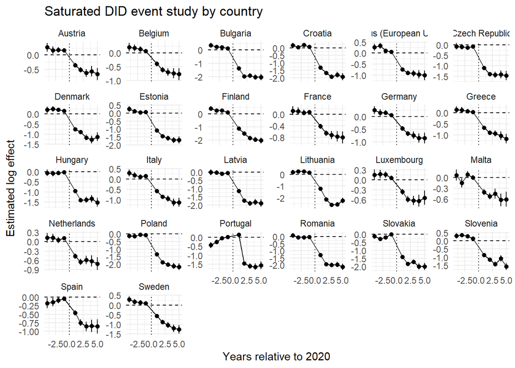

```r
library(broom)
library(dplyr)
library(stringr)
library(ggplot2)

plot_df <- broom::tidy(m_sat_event) %>%
  filter(str_detect(term, "^event_time::")) %>%
  mutate(
    event_time = as.integer(str_extract(term, "-?\\d+(?=:)")),
    country = str_extract(term, "(?<=treated_factor::).*"),
    conf.low = estimate - 1.96 * std.error,
    conf.high = estimate + 1.96 * std.error
  ) %>%
  filter(!is.na(country), country != "CONTROL")

ggplot(plot_df, aes(x = event_time, y = estimate)) +
  geom_hline(yintercept = 0, linetype = "dashed") +
  geom_vline(xintercept = 0, linetype = "dotted") +
  geom_point(size = 1.6) +
  geom_line() +
  geom_errorbar(
    aes(ymin = conf.low, ymax = conf.high),
    width = 0.15
  ) +
  facet_wrap(~ country, scales = "free_y") +
  theme_minimal() +
  labs(
    x = "Years relative to 2020",
    y = "Estimated log effect",
    title = "Saturated DID event study by country"
  )
```

## D-El from S-DID compared with mechanical and fee based

```
## `height` was translated to `width`.
```

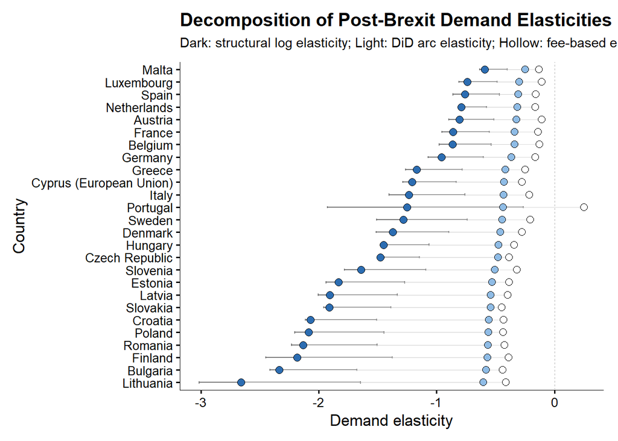

```r
library(dplyr)
library(ggplot2)
library(broom)

# 1. Brexit tuition shock

fee_pre  <- 9250
fee_post <- 22200

x <- log(fee_post/fee_pre)                     # log price change
pct_fee_change <- (fee_post - fee_pre) / fee_pre   # ≈ 1.40

# 2. Elasticities from DiD regression

did_df <- tidy(m_sat_DK, conf.int = TRUE) %>%
  filter(grepl("^treated_factor::", term)) %>%
  mutate(
    country = gsub("^treated_factor::", "", term),
    country = gsub(":Post$", "", country),

    beta = estimate,   # Δ log Q (DiD semi-elasticity)

    # 1) DiD quantity change (log change)
    log_change = beta,
    conf_low_log  = conf.low,
    conf_high_log = conf.high,

    # 2) DiD implied % quantity change
    pct_change_Q = exp(beta) - 1,

    # 3) Arc elasticity from DiD
    eta_arc_did = (exp(beta) - 1) / pct_fee_change,

    # 4) Structural log elasticity
    eta_log = beta / x
  ) %>%
  select(country, log_change, conf_low_log, conf_high_log,
         pct_change_Q, eta_arc_did, eta_log)


# 3. Mechanical fee-based elasticity

fee_df <- df %>%
  filter(Domicile_named_country %in% eu_real) %>%
  group_by(Domicile_named_country) %>%
  summarise(
    app_pre  = mean(Applicants[Year == 2020], na.rm = TRUE),
    app_post = mean(Applicants[Year == 2021], na.rm = TRUE),

    # η_mechanical = %ΔQ / %ΔP
    eta_mechanical = ((app_post - app_pre) / app_pre) / pct_fee_change,
    .groups = "drop"
  ) %>%
  rename(country = Domicile_named_country)

# 4. Merge data sets

plot_df <- did_df %>%
  left_join(fee_df, by = "country") %>%
  arrange(eta_log) %>%
  mutate(
    country = factor(country, levels = country),

    # small horizontal offsets so points don’t overlap
    eta_arc_shift  = eta_arc_did + 0.04,
    eta_mech_shift = eta_mechanical + 0.08
  )

# 5. Plot

ggplot(plot_df, aes(y = country)) +

  # zero line
  geom_vline(
    xintercept = 0,
    linetype = "dashed",
    color = "grey70",
    linewidth = 0.35
  ) +

  # confidence intervals (only structural elasticity has SEs)
  geom_errorbarh(
    aes(xmin = conf_low_log, xmax = conf_high_log),
    height = 0.16,
    linewidth = 0.4,
    color = "grey45"
  ) +

  # connectors between estimates
  geom_segment(
    aes(x = eta_log, xend = eta_arc_shift, yend = country),
    color = "grey80",
    linewidth = 0.3
  ) +
  geom_segment(
    aes(x = eta_arc_shift, xend = eta_mech_shift, yend = country),
    color = "grey85",
    linewidth = 0.3
  ) +

  # (A) Structural elasticity (log derivative)
  geom_point(
    aes(x = eta_log),
    shape = 21,
    size = 2.8,
    fill = "#2C6DB2",
    color = "black",
    stroke = 0.25
  ) +

  # (B) DiD arc elasticity
  geom_point(
    aes(x = eta_arc_shift),
    shape = 21,
    size = 2.6,
    fill = "#8FBCE6",
    color = "black",
    stroke = 0.25
  ) +

  # (C) Mechanical fee elasticity
  geom_point(
    aes(x = eta_mech_shift),
    shape = 21,
    size = 2.6,
    fill = "white",
    color = "black",
    stroke = 0.25
  ) +

  labs(
    title = "Decomposition of Post-Brexit Demand Elasticities",
    subtitle = "Dark: structural log elasticity; Light: DiD arc elasticity; Hollow: fee-based elasticity",
    x = "Demand elasticity",
    y = "Country"
  ) +

  theme_classic(base_size = 13) +
  theme(
    plot.title = element_text(face="bold", size=15, margin=margin(b=6)),
    plot.subtitle = element_text(size=11, margin=margin(b=10)),
    axis.text.y = element_text(size=10),
    axis.line = element_line(linewidth=0.35),
    plot.margin = margin(10,12,10,10)
  )
```

## S-DID design DE with COVID and Post-COVID coefficients

```r
df$Post_COVID <- as.integer(df$Year >= 2024)
df$Post <- as.integer(df$Year %in% c(2021,2023) )

#pooled control category (NO NA on RHS!)

df$treated_factor <- ifelse(
  df$Treated == 1,
  df$Domicile_named_country,   # each treated country gets its own coefficient
  "CONTROL"                     # all unaffected countries pooled
)

library(fixest)

m_sat_DK_2 <- feols(
  log(Applicants) ~
    i(treated_factor, Post, ref = "CONTROL") +
    i(treated_factor, Post_COVID, ref = "CONTROL") |
    Domicile_named_country + Year,
  data = df,
  panel.id = ~ Domicile_named_country + Year,
  vcov = "DK"
)
summary(m_sat_DK_2)
```

```
## OLS estimation, Dep. Var.: log(Applicants)
## Observations: 520
## Fixed-effects: Domicile_named_country: 52,  Year: 10
## Standard-errors: Driscoll-Kraay (L=1)
##                                                     Estimate Std. Error
## treated_factor::Austria:Post                       -0.536182   0.180196
## treated_factor::Belgium:Post                       -0.541977   0.193451
## treated_factor::Bulgaria:Post                      -1.461437   0.472609
## treated_factor::Croatia:Post                       -1.418180   0.416316
## treated_factor::Cyprus (European Union):Post       -0.806541   0.226245
## treated_factor::Czech Republic:Post                -0.977497   0.280219
## treated_factor::Denmark:Post                       -0.941301   0.273860
## treated_factor::Estonia:Post                       -1.182663   0.356483
## treated_factor::Finland:Post                       -1.418919   0.448790
## treated_factor::France:Post                        -0.524430   0.191062
## treated_factor::Germany:Post                       -0.594139   0.193974
## treated_factor::Greece:Post                        -0.718467   0.217354
## treated_factor::Hungary:Post                       -0.896355   0.308095
## treated_factor::Italy:Post                         -0.750527   0.252820
## treated_factor::Latvia:Post                        -1.207558   0.438330
## treated_factor::Lithuania:Post                     -1.698252   0.725565
## treated_factor::Luxembourg:Post                    -0.479315   0.174285
## treated_factor::Malta:Post                         -0.338632   0.101562
## treated_factor::Netherlands:Post                   -0.490065   0.151413
## treated_factor::Poland:Post                        -1.294742   0.435266
## treated_factor::Portugal:Post                      -0.368994   0.773753
## treated_factor::Romania:Post                       -1.318955   0.465741
## treated_factor::Slovakia:Post                      -1.153651   0.349872
## treated_factor::Slovenia:Post                      -1.142587   0.356407
## treated_factor::Spain:Post                         -0.460201   0.202735
## treated_factor::Sweden:Post                        -0.767306   0.278933
## treated_factor::Austria:Post_COVID                 -0.660062   0.140398
## treated_factor::Belgium:Post_COVID                 -0.746871   0.146857
## treated_factor::Bulgaria:Post_COVID                -1.854148   0.419742
## treated_factor::Croatia:Post_COVID                 -1.645842   0.342331
## treated_factor::Cyprus (European Union):Post_COVID -0.964618   0.213895
## treated_factor::Czech Republic:Post_COVID          -1.149954   0.255905
## treated_factor::Denmark:Post_COVID                 -1.184212   0.214189
## treated_factor::Estonia:Post_COVID                 -1.537096   0.300548
## treated_factor::Finland:Post_COVID                 -1.937626   0.338662
```

[output cut: 59 more lines]

```
## treated_factor::Lithuania:Post_COVID               -4.747080 0.00104847 **
## treated_factor::Luxembourg:Post_COVID              -4.071516 0.00279329 **
## treated_factor::Malta:Post_COVID                   -5.191547 0.00057047 ***
## treated_factor::Netherlands:Post_COVID             -4.300155 0.00199020 **
## treated_factor::Poland:Post_COVID                  -5.063232 0.00067806 ***
## treated_factor::Portugal:Post_COVID                -4.541446 0.00140301 **
## treated_factor::Romania:Post_COVID                 -4.635640 0.00122682 **
## treated_factor::Slovakia:Post_COVID                -4.779748 0.00100163 **
## treated_factor::Slovenia:Post_COVID                -4.255595 0.00212489 **
## treated_factor::Spain:Post_COVID                   -4.933295 0.00080966 ***
## treated_factor::Sweden:Post_COVID                  -5.974030 0.00020906 ***
## ---
## Signif. codes:  0 '***' 0.001 '**' 0.01 '*' 0.05 '.' 0.1 ' ' 1
## RMSE: 0.267096     Adj. R2: 0.938588
##                  Within R2: 0.562928
```

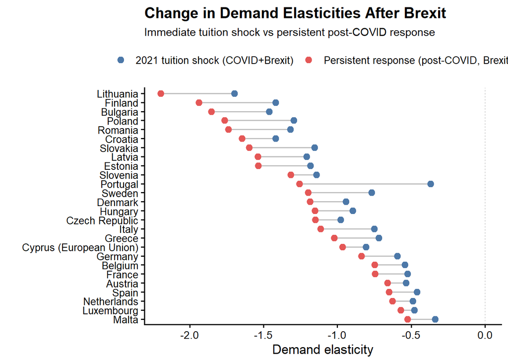

```r
library(dplyr)
library(ggplot2)
library(tidyr)
library(broom)
library(stringr)

# 1) extract coefficients
coef_long <- tidy(m_sat_DK_2) %>%
  filter(str_detect(term, "^treated_factor::")) %>%
  mutate(
    period = case_when(
      str_detect(term, "Post_COVID$") ~ "Post-COVID",
      str_detect(term, "Post$") ~ "Post-Brexit",
      TRUE ~ NA_character_
    ),
    country = term %>%
      str_remove("^treated_factor::") %>%
      str_remove(":(Post|Post_COVID)$"),
    elasticity = estimate
  ) %>%
  filter(!is.na(period))

# 2) wide version (for ordering + segments)
plot_df2 <- coef_long %>%
  select(country, period, elasticity) %>%
  pivot_wider(names_from = period, values_from = elasticity) %>%
  arrange(desc(`Post-COVID`)) %>%
  mutate(country = factor(country, levels = unique(country)))

# 3) long version (for legend + points)
plot_df_long <- plot_df2 %>%
  pivot_longer(
    cols = c(`Post-Brexit`, `Post-COVID`),
    names_to = "period",
    values_to = "elasticity"
  ) %>%
  mutate(
    period = factor(
      period,
      levels = c("Post-Brexit", "Post-COVID"),
      labels = c(
        "2021 tuition shock (COVID+Brexit)",
        "Persistent response (post-COVID, Brexit only)"
      )
    )
  )

# 4) plot
ggplot(plot_df_long, aes(y = country)) +

  # connecting lines (use wide data)
  geom_segment(
    data = plot_df2,
    aes(
      x = `Post-Brexit`,
      xend = `Post-COVID`,
      yend = country
    ),
    color = "grey75",
    linewidth = 0.6
  ) +

  # points with proper legend
  geom_point(
    aes(x = elasticity, color = period),
    size = 2.6
  ) +

  geom_vline(
    xintercept = 0,
    linetype = "dashed",
    color = "grey70",
    linewidth = 0.35
  ) +

  scale_color_manual(
    values = c("#4C78A8", "#E45756"),
    name = NULL
  ) +

  labs(
    title = "Change in Demand Elasticities After Brexit",
    subtitle = "Immediate tuition shock vs persistent post-COVID response",
    x = "Demand elasticity",
    y = ""
  ) +

  theme_classic(base_size = 13) +
  theme(
    plot.title = element_text(face = "bold", size = 15),
    plot.subtitle = element_text(size = 11),
    axis.text.y = element_text(size = 10),
    legend.position = "top",
    legend.text = element_text(size = 10)
  )
```

# Robustness

## Prepare the datasets

```r
data <- read_excel(
  "data_filtered.xlsx",
  sheet = "full_data"
)

data <- data %>%
  filter(!Domicile_named_country %in% c(
    "St Barthelemy", "St Martin (French part)", "Reunion",
    "Martinique", "Guadeloupe", "Aland Islands",
    "Cyprus (Not otherwise specified)",
    "French West Indies (Not In Use)",
    "Canary Islands", "French Guiana"
  ))


data_standard <- data %>%
  filter(Domicile_named_country %in% c(eu_real, eu_synth)) %>%
  mutate(
    EU = as.integer(Domicile_named_country %in% eu_real),
    control_group = "Synthetic"
  )

#very very poor countries
synth_poor <- c(
  "Pakistan", "Nepal", "Bangladesh", "Ethiopia",
  "Uganda", "Tanzania, United Republic of", "Rwanda", "Mozambique",
  "Malawi", "Sierra Leone",
  "Ghana", "Nigeria", "Kenya", "Zimbabwe"
)
data_poor <- data %>%
  filter(Domicile_named_country %in% c(eu_real, synth_poor)) %>%
  mutate(
    EU = as.integer(Domicile_named_country %in% eu_real),
    control_group = "Very_Poor"
  )
#very very rich countries

synth_rich <- c(
  "United States of America", "Canada", "Australia", "Norway",
  "Switzerland", "Singapore", "Qatar", "United Arab Emirates",
  "Kuwait", "Saudi Arabia", "Israel", "Japan",
  "Hong Kong"
)

data_rich <- data %>%
  filter(Domicile_named_country %in% c(eu_real, synth_rich)) %>%
  mutate(
    EU = as.integer(Domicile_named_country %in% eu_real),
    control_group = "Very_Rich"
  )

data_rich<-data_rich[data_rich$Year>2015,]
#OECD only
oecd <- c(
  "Australia", "Canada", "Chile",
  "Colombia",
  "Iceland", "Israel", "Japan",
  "Korea, Republic of", "Mexico",
  "New Zealand", "Norway",
  "Switzerland", "Turkey",
  "United States of America"
)
data_oecd <- data %>%
  filter(Domicile_named_country %in% c(eu_real, oecd)) %>%
  mutate(
    EU = as.integer(Domicile_named_country %in% eu_real),
    control_group = "OECD"
  )

data_oecd<-data_oecd[data_oecd$Year>2015,]
```

```r
library(dplyr)
library(fixest)

# --- core helper: filter to treated + a chosen control set, then run pooled DiD ---

run_pooled_did <- function(df, treated_vec, control_vec,
                           y = "Applicants",
                           post_year = 2021,
                           vcov_type = "DK") {

  df2 <- df %>%
    filter(Domicile_named_country %in% c(treated_vec, control_vec)) %>%
    mutate(
      EU   = as.integer(Domicile_named_country %in% treated_vec),
      Post = as.integer(Year >= post_year)
    )

  m <- feols(
    as.formula(paste0(
      "log(", y, ") ~ EU:Post | Domicile_named_country + Year"
    )),
    data = df2,
    panel.id = ~Domicile_named_country + Year,
    vcov = vcov_type
  )

  return(list(model = m, data = df2))
}
```

```r
controls_list <- list(
  "Original synthetic" = eu_synth,
  "Very poor controls" = synth_poor,
  "Very rich controls" = synth_rich,
  "OECD controls"      = setdiff(oecd, eu_real)  # keep OECD but remove treated EU from control pool
)
```

```r
fits <- lapply(names(controls_list), function(nm) {
  run_pooled_did(
    df = data[data$Year>2015,],
    treated_vec = eu_real,
    control_vec = controls_list[[nm]],
    y = "Applicants",
    post_year = 2021,
    vcov_type = "DK"
  )$model
})

names(fits) <- names(controls_list)
```

```r
get_ate <- function(m) {
  ct <- coeftable(m)

  data.frame(
    ATE = ct["EU:Post", "Estimate"],
    SE  = ct["EU:Post", "Std. Error"],
    t   = ct["EU:Post", "t value"],
    p   = ct["EU:Post", "Pr(>|t|)"],
    N   = nobs(m),
    R2_within = as.numeric(fitstat(m, "wr2"))
  )
}

ATE_table <- do.call(rbind, lapply(fits, get_ate))
ATE_table$Spec <- names(fits)
ATE_table <- ATE_table[, c("Spec","ATE","SE","t","p","N","R2_within")]

print(ATE_table)
```

```
##                                  Spec       ATE        SE          t
## Original synthetic Original synthetic -1.265119 0.1224580 -10.331044
## Very poor controls Very poor controls -1.671866 0.2038989  -8.199487
## Very rich controls Very rich controls -1.325263 0.1342102  -9.874539
## OECD controls           OECD controls -1.255891 0.1303421  -9.635350
##                               p   N R2_within
## Original synthetic 2.726825e-06 520 0.6128571
## Very poor controls 1.817125e-05 400 0.6284359
## Very rich controls 3.974346e-06 390 0.5873253
## OECD controls      4.870458e-06 400 0.5633532
```

## Bootstrapped ATE

```r
library(fixest)
library(dplyr)

set.seed(123)

eu_countries     <- intersect(unique(data$Domicile_named_country), eu_real)
non_eu_countries <- setdiff(unique(data$Domicile_named_country), eu_real)

B <- 1000
boot_ATE <- rep(NA_real_, B)

for (b in 1:B) {

  boot_eu  <- sample(eu_countries, length(eu_countries), replace = TRUE)
  boot_neu <- sample(non_eu_countries, length(non_eu_countries), replace = TRUE)

  boot_countries <- c(boot_eu, boot_neu)

  df_b <- data %>%
    filter(Domicile_named_country %in% boot_countries) %>%
    mutate(
      EU   = as.integer(Domicile_named_country %in% eu_real),
      Post = as.integer(Year >= 2021)
    )

m_b <- suppressMessages(
  suppressWarnings(
    feols(
      log(Applicants) ~ EU : Post |
        Domicile_named_country + Year,
      data = df_b,
      fixef.rm = "perfect"
    )
  )
)

  if ("EU:Post" %in% names(coef(m_b))) {
    boot_ATE[b] <- coef(m_b)["EU:Post"]
  }
}

boot_ATE_clean <- boot_ATE[!is.na(boot_ATE)]

# diagnostics
length(boot_ATE_clean) / B    # should be high (e.g. > 0.9)
```

```
## [1] 1
```

```r
# inference
quantile(boot_ATE_clean, c(0.025, 0.975))
```

```
##      2.5%     97.5%
## -1.412975 -1.113521
```

```r
sd(boot_ATE_clean)
```

```
## [1] 0.07822566
```

```r
mean(boot_ATE_clean)
```

```
## [1] -1.269757
```

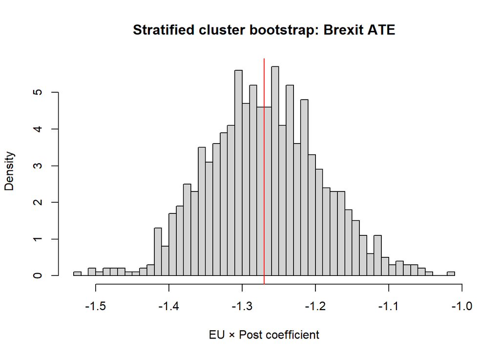

```r
#Option 1
hist(
  boot_ATE_clean,
  breaks = 40,
  main = "Stratified cluster bootstrap: Brexit ATE",
  xlab = "EU × Post coefficient",
  freq=FALSE
)
abline(v = 0, lty = 2)
abline(v = mean(boot_ATE_clean), col = "red")
```

## Callaway–Sant’Anna DR for different controls

```r
library(dplyr)
library(did)

run_cs <- function(dat, eu_vec = eu_real){

  dat2 <- dat %>%
    mutate(
      EU = as.integer(Domicile_named_country %in% eu_vec),
      id = as.numeric(factor(Domicile_named_country)),
      t  = Year,
      g  = ifelse(EU == 1, 2021, 0),
      log_app = log(Applicants)   # use log1p(Applicants) if you have zeros
    )

  att <- att_gt(
    yname  = "log_app",
    tname  = "t",
    idname = "id",est_method = "dr",
    gname  = "g",
    data   = dat2,
    panel  = TRUE
  )

  list(
    simple  = aggte(att, type = "simple"),
    dynamic = aggte(att, type = "dynamic")
  )
}

# --- run on each synthetic donor pool ---data_standard
res_st <- run_cs(data_standard[data_standard$Year>2015,])
res_poor <- run_cs(data_poor[data_poor$Year>2015,])
res_rich <- run_cs(data_rich)
res_oecd <- run_cs(data_oecd)

# --- print overall ATT ---
summary(res_st$simple)
```

```
##
## Call:
## aggte(MP = att, type = "simple")
##
## Reference: Callaway, Brantly and Pedro H.C. Sant'Anna.  "Difference-in-Differences with Multiple Time Periods." Journal of Econometrics, Vol. 225, No. 2, pp. 200-230, 2021. <https://doi.org/10.1016/j.jeconom.2020.12.001>, <https://arxiv.org/abs/1803.09015>
##
##
##      ATT    Std. Error     [ 95%  Conf. Int.]
##  -1.1974        0.1059     -1.405     -0.9898 *
##
##
## ---
## Signif. codes: `*' confidence band does not cover 0
##
## Control Group:  Never Treated,  Anticipation Periods:  0
## Estimation Method:  Doubly Robust
```

```r
summary(res_poor$simple)
```

```
##
## Call:
## aggte(MP = att, type = "simple")
##
## Reference: Callaway, Brantly and Pedro H.C. Sant'Anna.  "Difference-in-Differences with Multiple Time Periods." Journal of Econometrics, Vol. 225, No. 2, pp. 200-230, 2021. <https://doi.org/10.1016/j.jeconom.2020.12.001>, <https://arxiv.org/abs/1803.09015>
##
##
##      ATT    Std. Error     [ 95%  Conf. Int.]
##  -1.4782        0.1564    -1.7847     -1.1717 *
##
##
## ---
## Signif. codes: `*' confidence band does not cover 0
##
## Control Group:  Never Treated,  Anticipation Periods:  0
## Estimation Method:  Doubly Robust
```

```r
summary(res_rich$simple)
```

```
##
## Call:
## aggte(MP = att, type = "simple")
##
## Reference: Callaway, Brantly and Pedro H.C. Sant'Anna.  "Difference-in-Differences with Multiple Time Periods." Journal of Econometrics, Vol. 225, No. 2, pp. 200-230, 2021. <https://doi.org/10.1016/j.jeconom.2020.12.001>, <https://arxiv.org/abs/1803.09015>
##
##
##      ATT    Std. Error     [ 95%  Conf. Int.]
##  -1.2343        0.1218     -1.473     -0.9956 *
##
##
## ---
## Signif. codes: `*' confidence band does not cover 0
##
## Control Group:  Never Treated,  Anticipation Periods:  0
## Estimation Method:  Doubly Robust
```

```r
summary(res_oecd$simple)
```

```
##
## Call:
## aggte(MP = att, type = "simple")
##
## Reference: Callaway, Brantly and Pedro H.C. Sant'Anna.  "Difference-in-Differences with Multiple Time Periods." Journal of Econometrics, Vol. 225, No. 2, pp. 200-230, 2021. <https://doi.org/10.1016/j.jeconom.2020.12.001>, <https://arxiv.org/abs/1803.09015>
##
##
##      ATT    Std. Error     [ 95%  Conf. Int.]
##  -1.1865        0.1254    -1.4324     -0.9406 *
##
##
## ---
## Signif. codes: `*' confidence band does not cover 0
##
## Control Group:  Never Treated,  Anticipation Periods:  0
## Estimation Method:  Doubly Robust
```

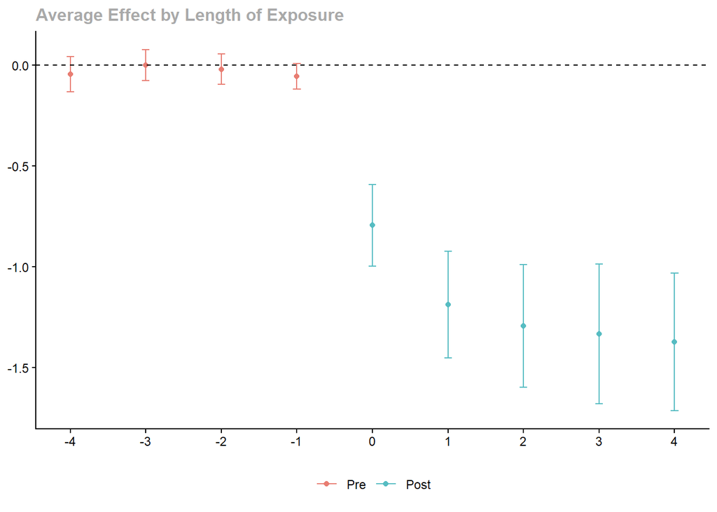

```r
# --- plot event-study style ATT ---
ggdid(res_st$dynamic)
```

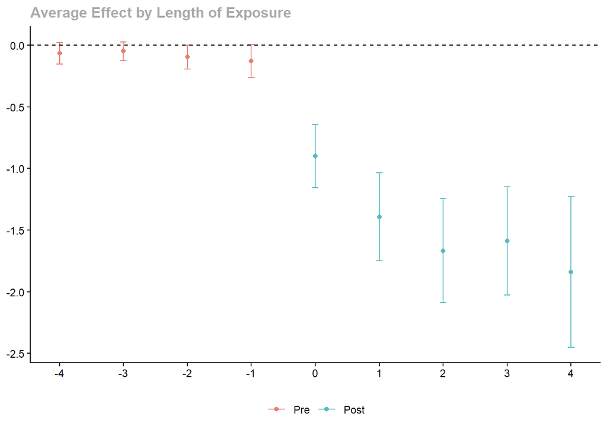

```r
ggdid(res_poor$dynamic)  # poor donor pool
```

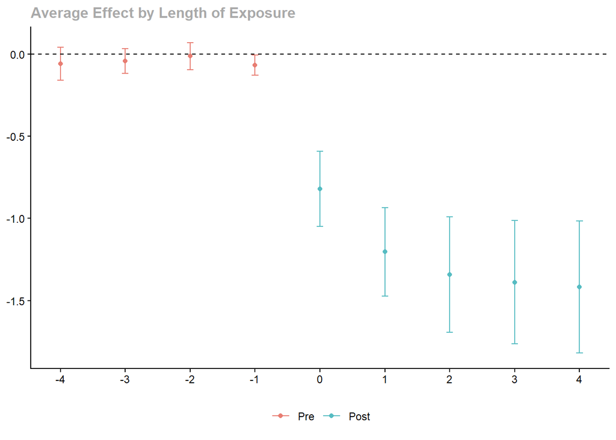

```r
ggdid(res_rich$dynamic)  # rich donor pool
```

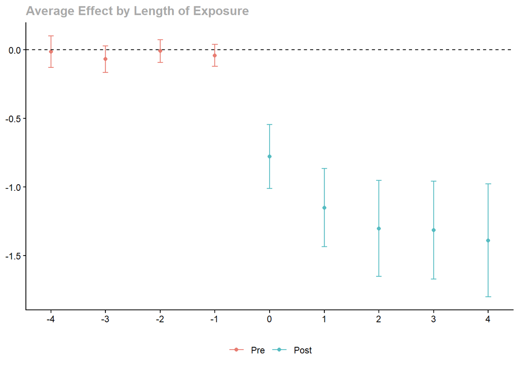

```r
ggdid(res_oecd$dynamic)  # OECD donor pool
```

```r
print("Baseline control group")
```

```
## [1] "Baseline control group"
```

```r
nrow(data_standard[data_standard$Year>2015,])
```

```
## [1] 520
```

```r
print("Number of entities")
```

```
## [1] "Number of entities"
```

```r
length(unique(data_standard[data_standard$Year>2015,]$Domicile_named_country))
```

```
## [1] 52
```

```r
print("vector lenght")
```

```
## [1] "vector lenght"
```

```r
length(eu_synth)
```

```
## [1] 26
```

```r
print("baseline vector lenght:")
```

```
## [1] "baseline vector lenght:"
```

```r
length(eu_real)
```

```
## [1] 26
```

```r
print("poor control group")
```

```
## [1] "poor control group"
```

```r
nrow(data_poor[data_poor$Year>2015,])
```

```
## [1] 400
```

```r
print("Number of entities")
```

```
## [1] "Number of entities"
```

```r
length(unique(data_poor[data_poor$Year>2015,]$Domicile_named_country))
```

```
## [1] 40
```

```r
print("vector lenght")
```

```
## [1] "vector lenght"
```

```r
length(synth_poor)
```

```
## [1] 14
```

```r
print("baseline vector lenght:")
```

```
## [1] "baseline vector lenght:"
```

```r
length(eu_real)
```

```
## [1] 26
```

```r
print("rich group")
```

```
## [1] "rich group"
```

```r
nrow(data_rich)
```

```
## [1] 390
```

```r
print("Number of entities")
```

```
## [1] "Number of entities"
```

```r
length(unique(data_rich$Domicile_named_country))
```

```
## [1] 39
```

```r
print("vector lenght")
```

```
## [1] "vector lenght"
```

```r
length(synth_rich)
```

```
## [1] 13
```

```r
print("baseline vector lenght:")
```

```
## [1] "baseline vector lenght:"
```

```r
length(eu_real)
```

```
## [1] 26
```

```r
print("oecd group")
```

```
## [1] "oecd group"
```

```r
nrow(data_oecd)
```

```
## [1] 400
```

```r
print("Number of entities")
```

```
## [1] "Number of entities"
```

```r
length(unique(data_oecd$Domicile_named_country))
```

```
## [1] 40
```

```r
print("vectoentities")
```

```
## [1] "vectoentities"
```

```r
length(oecd)
```

```
## [1] 14
```

```r
print("baseline vectorentities")
```

```
## [1] "baseline vectorentities"
```

```r
length(eu_real)
```

```
## [1] 26
```

## Omitted-variable sensitivity - sensemakr (Cinelli–Hazlett) {#sec-omitted-variable-sensitivity–sensemakr-(cinelli–hazlett}

```r
library(sensemakr)
df <- df %>%
  mutate(
    Post_2021 = Post + Post_COVID,
    EU = ifelse(Domicile_named_country %in% eu_real, 1, 0)
  )

m <- lm(
  log(Applicants) ~ EU:Post_2021 + as.factor(Domicile_named_country) + as.factor(Year),
  data = df
)


summary(m) # shows the estimated coefficient
```

```
##
## Call:
## lm(formula = log(Applicants) ~ EU:Post_2021 + as.factor(Domicile_named_country) +
##     as.factor(Year), data = df)
##
## Residuals:
##      Min       1Q   Median       3Q      Max
## -1.04993 -0.19131 -0.02188  0.21224  1.27839
##
## Coefficients:
##                                                           Estimate Std. Error
## (Intercept)                                                4.83399    0.11372
## as.factor(Domicile_named_country)Australia                 1.70635    0.14769
## as.factor(Domicile_named_country)Austria                   1.73339    0.14957
## as.factor(Domicile_named_country)Bahrain                   1.26833    0.14769
## as.factor(Domicile_named_country)Belgium                   2.28739    0.14957
## as.factor(Domicile_named_country)Bulgaria                  2.35712    0.14957
## as.factor(Domicile_named_country)Canada                    3.11488    0.14769
## as.factor(Domicile_named_country)Croatia                   0.67517    0.14957
## as.factor(Domicile_named_country)Cyprus (European Union)   3.12604    0.14957
## as.factor(Domicile_named_country)Czech Republic            2.08761    0.14957
## as.factor(Domicile_named_country)Denmark                   1.33393    0.14957
## as.factor(Domicile_named_country)Estonia                   0.90651    0.14957
## as.factor(Domicile_named_country)Finland                   1.48102    0.14957
## as.factor(Domicile_named_country)France                    3.89742    0.14957
## as.factor(Domicile_named_country)Germany                   3.41285    0.14957
## as.factor(Domicile_named_country)Greece                    2.95811    0.14957
## as.factor(Domicile_named_country)Hong Kong                 3.92721    0.14769
## as.factor(Domicile_named_country)Hungary                   1.94539    0.14957
## as.factor(Domicile_named_country)Ireland                   3.68581    0.14769
## as.factor(Domicile_named_country)Israel                    0.24862    0.14769
## as.factor(Domicile_named_country)Italy                     3.55909    0.14957
## as.factor(Domicile_named_country)Jersey                    1.57131    0.14769
## as.factor(Domicile_named_country)Jordan                    1.48433    0.14769
## as.factor(Domicile_named_country)Kuwait                    2.26904    0.14769
## as.factor(Domicile_named_country)Latvia                    1.24746    0.14957
## as.factor(Domicile_named_country)Lithuania                 2.09510    0.14957
## as.factor(Domicile_named_country)Luxembourg                1.42971    0.14957
## as.factor(Domicile_named_country)Macao                     0.59959    0.14769
## as.factor(Domicile_named_country)Malaysia                  3.58152    0.14769
```

[output cut: 87 more lines]

```
## as.factor(Year)2018                                         0.445  0.65633
## as.factor(Year)2019                                         0.519  0.60415
## as.factor(Year)2020                                         0.609  0.54291
## as.factor(Year)2021                                         3.137  0.00182 **
## as.factor(Year)2022                                        -6.810 3.07e-11 ***
## as.factor(Year)2023                                         0.979  0.32819
## as.factor(Year)2024                                         0.833  0.40539
## as.factor(Year)2025                                         0.325  0.74556
## EU:Post_2021                                              -17.896  < 2e-16 ***
## ---
## Signif. codes:  0 '***' 0.001 '**' 0.01 '*' 0.05 '.' 0.1 ' ' 1
##
## Residual standard error: 0.3302 on 458 degrees of freedom
## Multiple R-squared:  0.9352, Adjusted R-squared:  0.9265
## F-statistic: 108.3 on 61 and 458 DF,  p-value: < 2.2e-16
```

```r
sensemakr(m, treatment = "EU:Post_2021")
```

```
## Sensitivity Analysis to Unobserved Confounding
##
## Model Formula: log(Applicants) ~ EU:Post_2021 + as.factor(Domicile_named_country) +
##     as.factor(Year)
##
## Null hypothesis: q = 1 and reduce = TRUE
##
## Unadjusted Estimates of ' EU:Post_2021 ':
##   Coef. estimate: -1.05806
##   Standard Error: 0.05912
##   t-value: -17.8961
##
## Sensitivity Statistics:
##   Partial R2 of treatment with outcome: 0.41152
##   Robustness Value, q = 1 : 0.55674
##   Robustness Value, q = 1 alpha = 0.05 : 0.51718
##
## For more information, check summary.
```

To assess the robustness of the estimated treatment effect to omitted variable bias, we apply the `sensemakr` framework. This approach evaluates how strong an unobserved confounder would need to be, in terms of its residual association with both the treatment and the outcome, to alter the substantive conclusions. We construct the sensitivity object. Let $U$ denote a hypothetical omitted confounder. The sensitivity analysis evaluates the partial $R^2$ of $U$ with the outcome conditional on the treatment and observed covariates,

$$R^2_{Y \sim U \mid X,D}$$

and the partial $R^2$ of $U$ with the treatment conditional on observed covariates,

$$R^2_{D \sim U \mid X}$$

where $D = EU_i \times Post2021_t$ is the treatment interaction and $X$ includes the country and year fixed effects.

The robustness value summarizes the minimum strength that an omitted confounder must have, jointly with the treatment and outcome, to overturn the inference. This quantity represents the smallest combination of $R^2_{Y \sim U \mid X,D}$ and $R^2_{D \sim U \mid X}$ that would render the treatment effect statistically insignificant.

We also compute the robustness value required to reduce the point estimate to zero:

Setting $q = 1$ asks how strong an omitted confounder would need to be to fully explain away the estimated effect, i.e.

$$\hat{\beta}_1^{adjusted} = 0$$

The sensitivity plot visualizes combinations of partial $R^2$ values for a hypothetical omitted confounder that would be sufficient to attenuate the estimate or its statistical significance.

```r
library(sensemakr)

m <- lm(log(Applicants) ~ EU:Post_2021+as.factor(Domicile_named_country)+as.factor(Year), data = df)

# Sensitivity object (optional, for plots etc.)
s <- sensemakr(m, treatment = "EU:Post_2021")

# Robustness value: pass the MODEL (m), not s
robustness_value(m, treatment = "EU:Post_2021")
```

```
##                                               (Intercept)
##                                                   0.81492
##                as.factor(Domicile_named_country)Australia
##                                                   0.35872
##                  as.factor(Domicile_named_country)Austria
##                                                   0.35975
##                  as.factor(Domicile_named_country)Bahrain
##                                                   0.26519
##                  as.factor(Domicile_named_country)Belgium
##                                                   0.45830
##                 as.factor(Domicile_named_country)Bulgaria
##                                                   0.46943
##                   as.factor(Domicile_named_country)Canada
##                                                   0.57948
##                  as.factor(Domicile_named_country)Croatia
##                                                   0.11213
##  as.factor(Domicile_named_country)Cyprus (European Union)
##                                                   0.57604
##           as.factor(Domicile_named_country)Czech Republic
##                                                   0.42488
##                  as.factor(Domicile_named_country)Denmark
##                                                   0.27631
##                  as.factor(Domicile_named_country)Estonia
##                                                   0.17386
##                  as.factor(Domicile_named_country)Finland
##                                                   0.30834
##                   as.factor(Domicile_named_country)France
##                                                   0.65815
##                  as.factor(Domicile_named_country)Germany
##                                                   0.60912
##                   as.factor(Domicile_named_country)Greece
##                                                   0.55510
##                as.factor(Domicile_named_country)Hong Kong
##                                                   0.66548
##                  as.factor(Domicile_named_country)Hungary
##                                                   0.39967
##                  as.factor(Domicile_named_country)Ireland
##                                                   0.64239
##                   as.factor(Domicile_named_country)Israel
##                                                   0.00000
```

[output cut: 70 more lines]

```
##                                       as.factor(Year)2020
##                                                   0.00000
##                                       as.factor(Year)2021
##                                                   0.05319
##                                       as.factor(Year)2022
##                                                   0.20214
##                                       as.factor(Year)2023
##                                                   0.00000
##                                       as.factor(Year)2024
##                                                   0.00000
##                                       as.factor(Year)2025
##                                                   0.00000
##                                              EU:Post_2021
##                                                   0.51718
## Parameters: q = 1, alpha = 0.05, invert = FALSE
```

```r
robustness_value(m, treatment = "EU:Post_2021", q = 1)  # for "reduce estimate to 0"
```

```
##                                               (Intercept)
##                                                   0.81492
##                as.factor(Domicile_named_country)Australia
##                                                   0.35872
##                  as.factor(Domicile_named_country)Austria
##                                                   0.35975
##                  as.factor(Domicile_named_country)Bahrain
##                                                   0.26519
##                  as.factor(Domicile_named_country)Belgium
##                                                   0.45830
##                 as.factor(Domicile_named_country)Bulgaria
##                                                   0.46943
##                   as.factor(Domicile_named_country)Canada
##                                                   0.57948
##                  as.factor(Domicile_named_country)Croatia
##                                                   0.11213
##  as.factor(Domicile_named_country)Cyprus (European Union)
##                                                   0.57604
##           as.factor(Domicile_named_country)Czech Republic
##                                                   0.42488
##                  as.factor(Domicile_named_country)Denmark
##                                                   0.27631
##                  as.factor(Domicile_named_country)Estonia
##                                                   0.17386
##                  as.factor(Domicile_named_country)Finland
##                                                   0.30834
##                   as.factor(Domicile_named_country)France
##                                                   0.65815
##                  as.factor(Domicile_named_country)Germany
##                                                   0.60912
##                   as.factor(Domicile_named_country)Greece
##                                                   0.55510
##                as.factor(Domicile_named_country)Hong Kong
##                                                   0.66548
##                  as.factor(Domicile_named_country)Hungary
##                                                   0.39967
##                  as.factor(Domicile_named_country)Ireland
##                                                   0.64239
##                   as.factor(Domicile_named_country)Israel
##                                                   0.00000
```

[output cut: 70 more lines]

```
##                                       as.factor(Year)2020
##                                                   0.00000
##                                       as.factor(Year)2021
##                                                   0.05319
##                                       as.factor(Year)2022
##                                                   0.20214
##                                       as.factor(Year)2023
##                                                   0.00000
##                                       as.factor(Year)2024
##                                                   0.00000
##                                       as.factor(Year)2025
##                                                   0.00000
##                                              EU:Post_2021
##                                                   0.51718
## Parameters: q = 1, alpha = 0.05, invert = FALSE
```

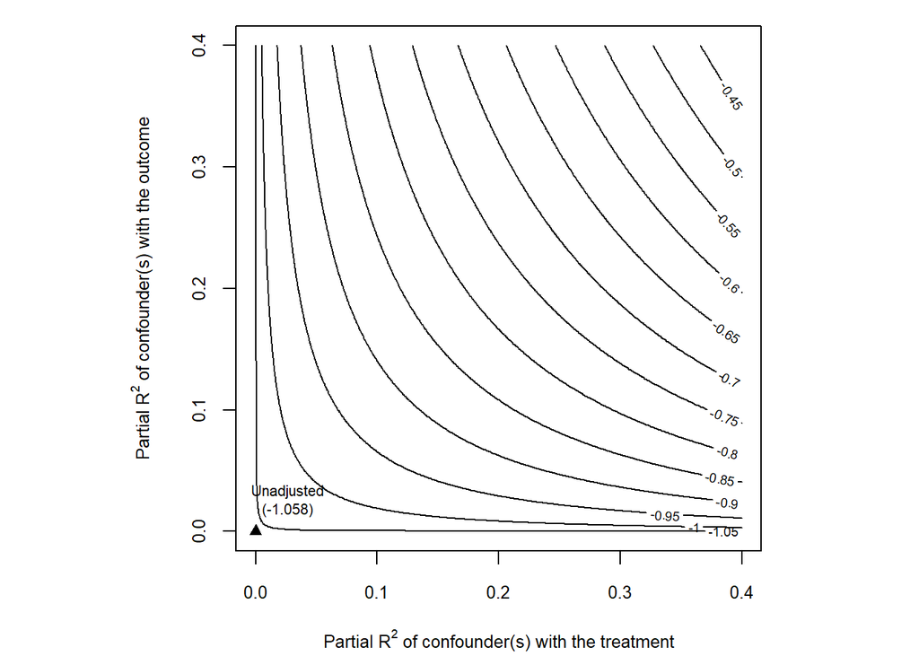

```r
plot(s)
```

```r
summary(summary(sensemakr(m, treatment = "EU:Post_2021")))
```

```
## Sensitivity Analysis to Unobserved Confounding
##
## Model Formula: log(Applicants) ~ EU:Post_2021 + as.factor(Domicile_named_country) +
##     as.factor(Year)
##
## Null hypothesis: q = 1 and reduce = TRUE
## -- This means we are considering biases that reduce the absolute value of the current estimate.
## -- The null hypothesis deemed problematic is H0:tau = 0
##
## Unadjusted Estimates of 'EU:Post_2021':
##   Coef. estimate: -1.0581
##   Standard Error: 0.0591
##   t-value (H0:tau = 0): -17.8961
##
## Sensitivity Statistics:
##   Partial R2 of treatment with outcome: 0.4115
##   Robustness Value, q = 1: 0.5567
##   Robustness Value, q = 1, alpha = 0.05: 0.5172
##
## Verbal interpretation of sensitivity statistics:
##
## -- Partial R2 of the treatment with the outcome: an extreme confounder (orthogonal to the covariates) that explains 100% of the residual variance of the outcome, would need to explain at least 41.15% of the residual variance of the treatment to fully account for the observed estimated effect.
##
## -- Robustness Value, q = 1: unobserved confounders (orthogonal to the covariates) that explain more than 55.67% of the residual variance of both the treatment and the outcome are strong enough to bring the point estimate to 0 (a bias of 100% of the original estimate). Conversely, unobserved confo…
##
## -- Robustness Value, q = 1, alpha = 0.05: unobserved confounders (orthogonal to the covariates) that explain more than 51.72% of the residual variance of both the treatment and the outcome are strong enough to bring the estimate to a range where it is no longer 'statistically different' from 0 (a…
```

```
## Length  Class   Mode
##      0   NULL   NULL
```

```r
ovb_minimal_reporting(s, format = "latex")
```

```
## \begin{table}[!h]
## \centering
## \begin{tabular}{lrrrrrr}
## \multicolumn{7}{c}{Outcome: \textit{Applicants}} \\
## \hline \hline
## Treatment: & Est. & S.E. & t-value & $R^2_{Y \sim D |{\bf X}}$ & $RV_{q = 1}$ & $RV_{q = 1, \alpha = 0.05}$  \\
## \hline
## \textit{EU:Post_2021} & -1.058 & 0.059 & -17.896 & 41.2\% & 55.7\% & 51.7\% \\
## \hline
## df = 458 & & \multicolumn{5}{r}{ }\end{tabular}
## \end{table}
```

# ATE wealth heterogeneity

## Constructing the database

```r
library(WDI)
library(WDI)
library(countrycode)

data<-data_UCAS
# years actually present in the data
yr_min <- min(data$Year, na.rm = TRUE)
yr_max <- min(max(data$Year, na.rm = TRUE), 2024)  # cap to available WB years if needed

# only pull countries that are in the data set
iso_list <- data %>%
  mutate(iso3c = countrycode(Domicile_named_country, "country.name", "iso3c")) %>%
  filter(!is.na(iso3c)) %>%
  distinct(iso3c) %>%
  pull(iso3c)

wb_indicators <- c(
  GDPpc = "NY.GDP.PCAP.KD",      # GDP per capita, constant USD
  Pop15_65 = "SP.POP.1564.TO",
  YouthUnempl = "SL.UEM.1524.ZS"
)

controls <- WDI(
  country = iso_list,
  indicator = wb_indicators,
  start = yr_min,
  end = yr_max,
  extra = TRUE
) %>%
  transmute(
    iso3c,
    Year = year,
    GDPpc,
    Pop15_65,
    YouthUnempl
  )
data_controls <- data %>%
  mutate(iso3c = countrycode(Domicile_named_country, "country.name", "iso3c")) %>%
  left_join(controls, by = c("iso3c", "Year"))
```

## ATE wealth heterogeneity FO

```r
library(fixest)
library(dplyr)
library(modelsummary)

# Base Panel Data set
data_panel <- data_controls %>%
  mutate(
    log_app = log(Applicants),
    EU = as.numeric(Domicile_named_country %in% eu_real),
    Post = as.numeric(Year >= 2021),
    did = EU * Post
  ) %>%
  filter(!is.na(log_app))

# M1 — Clean baseline DiD
m1 <- feols(
  log_app ~ did | Domicile_named_country + Year,
  data = data_panel,
  panel.id = ~Domicile_named_country + Year,
  vcov = "DK"
)

# M2 — Add GDP
m2 <- feols(
  log_app ~ did + log(GDPpc) | Domicile_named_country + Year,
  data = data_panel,
  panel.id = ~Domicile_named_country + Year,
  vcov = "DK"
)
```

```
## NOTE: 61 observations removed because of NA values (RHS: 61).
```

```r
# M4 — Add Pop15_65
m4 <- feols(
  log_app ~ did + log(GDPpc) + log(Pop15_65) | Domicile_named_country + Year,
  data = data_panel,
  panel.id = ~Domicile_named_country + Year,
  vcov = "DK"
)
```

```
## NOTE: 61 observations removed because of NA values (RHS: 61).
```

```r
# M5 — Add YouthUnempl + Pop15_65
m5 <- feols(
  log_app ~ did + log(GDPpc) + YouthUnempl + log(Pop15_65) | Domicile_named_country + Year,
  data = data_panel,
  panel.id = ~Domicile_named_country + Year,
  vcov = "DK"
)
```

```
## NOTE: 61 observations removed because of NA values (RHS: 61).
```

```r
# M6 — Fully interacted structural channels
m6 <- feols(
  log_app ~ did * (log(GDPpc) + log(Pop15_65) + YouthUnempl) | Domicile_named_country + Year,
  data = data_panel,
  panel.id = ~Domicile_named_country + Year,
  vcov = "DK"
)
```

```
## NOTE: 61 observations removed because of NA values (RHS: 61).
```

```r
modelsummary(
  list(
    "M1" = m1,
    "M2" = m2,
    "M4" = m4,
    "M5" = m5,
    "M6" = m6
  ),
  stars = TRUE,
  output = "default"
)
```

|  | M1 | M2 | M4 | M5 | M6 |
| --- | --- | --- | --- | --- | --- |
| did | -1.265*** | -1.215*** | -1.112*** | -1.095*** | -7.155*** |
|  | (0.122) | (0.133) | (0.103) | (0.098) | (0.703) |
| log(GDPpc) |  | -0.377 | 0.102 | -0.047 | 0.281* |
|  |  | (0.260) | (0.127) | (0.151) | (0.119) |
| log(Pop15_65) |  |  | 3.760*** | 4.029*** | 3.498*** |
|  |  |  | (0.382) | (0.300) | (0.381) |
| YouthUnempl |  |  |  | -0.022*** | -0.015** |
|  |  |  |  | (0.004) | (0.004) |
| did × log(GDPpc) |  |  |  |  | 0.438*** |
|  |  |  |  |  | (0.073) |
| did × log(Pop15_65) |  |  |  |  | 0.094*** |
|  |  |  |  |  | (0.017) |
| did × YouthUnempl |  |  |  |  | 0.006 |
|  |  |  |  |  | (0.006) |
| Num.Obs. | 520 | 459 | 459 | 459 | 459 |
| R2 | 0.957 | 0.960 | 0.968 | 0.970 | 0.975 |
| R2 Adj. | 0.952 | 0.954 | 0.963 | 0.965 | 0.971 |
| R2 Within | 0.613 | 0.613 | 0.688 | 0.706 | 0.761 |
| R2 Within Adj. | 0.612 | 0.612 | 0.686 | 0.703 | 0.757 |
| AIC | 163.7 | 122.8 | 25.8 | 1.8 | -88.7 |
| BIC | 427.4 | 374.7 | 281.9 | 261.9 | 183.8 |
| RMSE | 0.25 | 0.24 | 0.22 | 0.21 | 0.19 |
| Std.Errors | Driscoll-Kraay (L=1) | Driscoll-Kraay (L=1) | Driscoll-Kraay (L=1) | Driscoll-Kraay (L=1) | Driscoll-Kraay (L=1) |
| FE: Domicile_named_country | X | X | X | X | X |
| FE: Year | X | X | X | X | X |

+ p < 0.1, * p < 0.05, ** p < 0.01, *** p < 0.001

```r
m_pois1 <- fepois(
  Applicants ~ did | Domicile_named_country + Year,
  data = data_panel,
  panel.id = ~Domicile_named_country + Year,
  vcov = "DK"
)
m_pois2 <- fepois(
  Applicants ~ did + log(GDPpc) + log(Pop15_65) + YouthUnempl |
  Domicile_named_country + Year,
  data = data_panel,
  panel.id = ~Domicile_named_country + Year,
  vcov = "DK"
)
```

```
## NOTE: 61 observations removed because of NA values (RHS: 61).
```

```r
m_pois3 <- fepois(
  Applicants ~ did*(log(GDPpc) + log(Pop15_65) + YouthUnempl) |
  Domicile_named_country + Year,
  data = data_panel,
  panel.id = ~Domicile_named_country + Year,
  vcov = "DK"
)
```

```
## NOTE: 61 observations removed because of NA values (RHS: 61).
```

```r
modelsummary(
  list(
    "M1" = m_pois1,
    "M2" = m_pois2,
    "M3"=m_pois3
  ),
  stars = TRUE,
  output = "default"
)
```

|  | M1 | M2 | M3 |
| --- | --- | --- | --- |
| did | -1.132*** | -0.994*** | -7.367*** |
|  | (0.126) | (0.109) | (1.175) |
| log(GDPpc) |  | -0.730* | -0.288 |
|  |  | (0.288) | (0.250) |
| log(Pop15_65) |  | 2.774*** | 2.341*** |
|  |  | (0.519) | (0.534) |
| YouthUnempl |  | -0.018** | -0.012* |
|  |  | (0.006) | (0.006) |
| did × log(GDPpc) |  |  | 0.470*** |
|  |  |  | (0.102) |
| did × log(Pop15_65) |  |  | 0.078*** |
|  |  |  | (0.015) |
| did × YouthUnempl |  |  | 0.015*** |
|  |  |  | (0.004) |
| Num.Obs. | 520 | 459 | 459 |
| R2 | 0.952 | 0.964 | 0.970 |
| R2 Adj. | 0.952 | 0.964 | 0.969 |
| R2 Within | 0.590 | 0.670 | 0.718 |
| R2 Within Adj. | 0.590 | 0.670 | 0.718 |
| AIC | 39900.2 | 25735.4 | 22015.0 |
| BIC | 40163.9 | 25995.5 | 22287.5 |
| RMSE | 382.35 | 325.10 | 299.70 |
| Std.Errors | Driscoll-Kraay (L=1) | Driscoll-Kraay (L=1) | Driscoll-Kraay (L=1) |
| FE: Domicile_named_country | X | X | X |
| FE: Year | X | X | X |

+ p < 0.1, * p < 0.05, ** p < 0.01, *** p < 0.001

```r
library(fixest)
library(dplyr)
library(modelsummary)

# ----------------------------
# 1. build clean analysis data
# ----------------------------
df_sat <- data_panel %>%
  mutate(
    Domicile_named_country = as.character(Domicile_named_country),
    Year = as.integer(Year),

    Applicants = as.numeric(Applicants),
    GDPpc = as.numeric(GDPpc),
    YouthUnempl = as.numeric(YouthUnempl),

    # handle either Pop15_64 or Pop15_65 if naming differs
    Pop_working_age =as.numeric(Pop15_65),

    log_app = log(Applicants),

    # treatment
    Post = as.integer(Year >= 2021),
    Treated = as.integer(Domicile_named_country %in% eu_real),

    # pooled control group for saturated DiD
    treated_factor = ifelse(
      Treated == 1,
      Domicile_named_country,
      "CONTROL"
    ),

    # logs of controls
    log_GDPpc = log(GDPpc),
    log_Pop_working_age = log(Pop_working_age)
  ) %>%
  filter(
    !is.na(log_app),
    !is.na(Post),
    !is.na(treated_factor)
  )

# optional check
table(df_sat$treated_factor == "CONTROL")
```

```
##
## FALSE  TRUE
##   260   260
```

```r
sort(unique(df_sat$treated_factor))[1:10]
```

```
##  [1] "Austria"                 "Belgium"
##  [3] "Bulgaria"                "CONTROL"
##  [5] "Croatia"                 "Cyprus (European Union)"
##  [7] "Czech Republic"          "Denmark"
##  [9] "Estonia"                 "Finland"
```

```r
# ----------------------------
# 2. saturated DiD models
# ----------------------------

# S1: saturated DiD only
s1 <- feols(
  log_app ~ i(treated_factor, Post, ref = "CONTROL") |
    Domicile_named_country + Year,
  data = df_sat,
  panel.id = ~ Domicile_named_country + Year,
  vcov = "DK"
)
# S2: add GDP
s2 <- feols(
  log_app ~ i(treated_factor, Post, ref = "CONTROL") + log_GDPpc |
    Domicile_named_country + Year,
  data = df_sat %>% filter(!is.na(log_GDPpc)),
  panel.id = ~ Domicile_named_country + Year,
  vcov = "DK"
)
# S3: add GDP + working-age population
s3 <- feols(
  log_app ~ i(treated_factor, Post, ref = "CONTROL") +
    log_GDPpc + log_Pop_working_age |
    Domicile_named_country + Year,
  data = df_sat %>% filter(!is.na(log_GDPpc), !is.na(log_Pop_working_age)),
  panel.id = ~ Domicile_named_country + Year,
  vcov = "DK"
)
# S4: add GDP + working-age population + youth unemployment
s4 <- feols(
  log_app ~ i(treated_factor, Post, ref = "CONTROL") +
    log_GDPpc + log_Pop_working_age + YouthUnempl |
    Domicile_named_country + Year,
  data = df_sat %>% filter(
    !is.na(log_GDPpc),
    !is.na(log_Pop_working_age),
    !is.na(YouthUnempl)
  ),
  panel.id = ~ Domicile_named_country + Year,
  vcov = "DK"
)
modelsummary(
  list(
    "S1 Saturated DiD" = s1,
    "S2 + GDPpc" = s2,
    "S3 + GDPpc + Pop" = s3,
    "S4 + GDPpc + Pop + YouthUnempl" = s4
  ),
  stars = TRUE,
  output = "default"
)
```

|  | S1 Saturated DiD | S2 + GDPpc | S3 + GDPpc + Pop | S4 + GDPpc + Pop + YouthUnempl |
| --- | --- | --- | --- | --- |
| treated_factor = Austria × Post | -0.705*** | -0.676*** | -0.617*** | -0.586*** |
|  | (0.084) | (0.092) | (0.066) | (0.069) |
| treated_factor = Belgium × Post | -0.759*** | -0.730*** | -0.695*** | -0.672*** |
|  | (0.097) | (0.105) | (0.082) | (0.090) |
| treated_factor = Bulgaria × Post | -2.043*** | -2.011*** | -1.825*** | -1.788*** |
|  | (0.163) | (0.177) | (0.124) | (0.123) |
| treated_factor = Croatia × Post | -1.811*** | -1.774*** | -1.576*** | -1.594*** |
|  | (0.134) | (0.147) | (0.116) | (0.118) |
| treated_factor = Cyprus (European Union) × Post | -1.058*** | -1.043*** | -1.096*** | -1.141*** |
|  | (0.100) | (0.099) | (0.115) | (0.148) |
| treated_factor = Czech Republic × Post | -1.293*** | -1.270*** | -1.169*** | -1.139*** |
|  | (0.065) | (0.077) | (0.075) | (0.067) |
| treated_factor = Denmark × Post | -1.203*** | -1.184*** | -1.150*** | -1.131*** |
|  | (0.136) | (0.160) | (0.137) | (0.126) |
| treated_factor = Estonia × Post | -1.604*** | -1.561*** | -1.513*** | -1.439*** |
|  | (0.147) | (0.162) | (0.136) | (0.115) |
| treated_factor = Finland × Post | -1.913*** | -1.827*** | -1.729*** | -1.741*** |
|  | (0.237) | (0.255) | (0.208) | (0.200) |
| treated_factor = France × Post | -0.753*** | -0.723*** | -0.654*** | -0.676*** |
|  | (0.088) | (0.098) | (0.063) | (0.068) |
| treated_factor = Germany × Post | -0.838*** | -0.806*** | -0.668*** | -0.649*** |
|  | (0.104) | (0.114) | (0.059) | (0.055) |
| treated_factor = Greece × Post | -1.022*** | -0.971*** | -0.802*** | -0.903*** |
|  | (0.106) | (0.092) | (0.046) | (0.103) |
| treated_factor = Hungary × Post | -1.271*** | -1.229*** | -1.081*** | -1.028*** |
|  | (0.091) | (0.098) | (0.081) | (0.090) |
| treated_factor = Italy × Post | -1.081*** | -1.036*** | -0.910*** | -0.988*** |
|  | (0.143) | (0.148) | (0.099) | (0.139) |
| treated_factor = Latvia × Post | -1.668*** | -1.626*** | -1.446*** | -1.420*** |
|  | (0.148) | (0.174) | (0.134) | (0.133) |
| treated_factor = Lithuania × Post | -2.329*** | -2.317*** | -2.269*** | -2.247*** |
|  | (0.303) | (0.371) | (0.363) | (0.346) |
| treated_factor = Luxembourg × Post | -0.649*** | -0.651*** | -0.764*** | -0.748*** |
|  | (0.072) | (0.089) | (0.109) | (0.098) |
| treated_factor = Malta × Post | -0.518*** | -0.505*** | -0.751*** | -0.753*** |
|  | (0.051) | (0.042) | (0.132) | (0.128) |
| treated_factor = Netherlands × Post | -0.691*** | -0.670*** | -0.654*** | -0.632*** |
|  | (0.050) | (0.049) | (0.040) | (0.045) |
| treated_factor = Poland × Post | -1.825*** | -1.769*** | -1.560*** | -1.537*** |
|  | (0.167) | (0.175) | (0.135) | (0.126) |
| treated_factor = Portugal × Post | -1.095* | -1.013+ | -0.943+ | -0.935+ |
|  | (0.367) | (0.443) | (0.429) | (0.423) |
| treated_factor = Romania × Post | -1.868*** | -1.808*** | -1.642*** | -1.551*** |
|  | (0.160) | (0.173) | (0.139) | (0.126) |
| treated_factor = Slovakia × Post | -1.673*** | -1.623*** | -1.454*** | -1.400*** |
|  | (0.126) | (0.121) | (0.102) | (0.100) |
| treated_factor = Slovenia × Post | -1.436*** | -1.354*** | -1.272*** | -1.249*** |
|  | (0.152) | (0.150) | (0.127) | (0.125) |
| treated_factor = Spain × Post | -0.664*** | -0.640*** | -0.624*** | -0.702*** |
|  | (0.087) | (0.104) | (0.095) | (0.118) |
| treated_factor = Sweden × Post | -1.123*** | -1.058*** | -1.056*** | -0.996*** |
|  | (0.170) | (0.177) | (0.157) | (0.139) |
| log_GDPpc |  | 0.060 | 0.359* | 0.275+ |
|  |  | (0.225) | (0.146) | (0.123) |
| log_Pop_working_age |  |  | 2.722*** | 2.902*** |
|  |  |  | (0.492) | (0.463) |
| YouthUnempl |  |  |  | -0.012* |
|  |  |  |  | (0.004) |
| Num.Obs. | 520 | 459 | 459 | 459 |
| R2 | 0.978 | 0.980 | 0.983 | 0.984 |
| R2 Adj. | 0.974 | 0.976 | 0.979 | 0.980 |
| R2 Within | 0.802 | 0.807 | 0.838 | 0.842 |
| R2 Within Adj. | 0.791 | 0.793 | 0.826 | 0.830 |
| AIC | -136.1 | -146.9 | -224.8 | -234.6 |
| BIC | 234.0 | 208.2 | 134.4 | 128.7 |
| RMSE | 0.18 | 0.17 | 0.16 | 0.15 |
| Std.Errors | Driscoll-Kraay (L=1) | Driscoll-Kraay (L=1) | Driscoll-Kraay (L=1) | Driscoll-Kraay (L=1) |
| FE: Domicile_named_country | X | X | X | X |
| FE: Year | X | X | X | X |

+ p < 0.1, * p < 0.05, ** p < 0.01, *** p < 0.001